# Rural environment Paper

We plan a paper on the rural environment, based on data here: https://docs.google.com/document/d/18f048q1x7UAKwgjXP7UNRuAT6Ad3XBXZHAi3dFYO2U4/edit#heading=h.n0uc8s3dggzu .

# Setup

```r
library(stringr)
library(rstatix)
library(foreign)
library(stringr)
library(dplyr)
```

```r
library(ggplot2)
library(data.table)
```

Set directories

```r
Sys.setenv(R_CONFIG_ACTIVE = Sys.info()["nodename"])
data_dir <- config::get("rural_data_dir")
hints5_filepath <- config::get("hints_protected_data_folderpath")
```

## Setup the ORFCS dataset

```r
source("orfcs_utilities.R")
library(magrittr)
library(dplyr)


preprocessed_data_filepath <- paste0(data_dir,"cloudresearch_survey_results/orfcs_preprocessed2_anon_by_subj.csv")
library(readr)
library(ggplot2)
library(GGally)
orfcs_dataset <- readr::read_csv(preprocessed_data_filepath)
#have to do this here because the file was saved in CSV, which converts factors to strings.
orfcs_dataset$Education_Categorical<-factor(
  orfcs_dataset$Education_Categorical,
  #levels=3:9,
  labels=c("No high school diploma",
           "High school diploma/GED",
           "Some college credit, no degree",
           "Trade, technical, or vocational training",
           "Associate's degree",
           "Bachelor's degree",
           "Master's, Professional, or doctoral degree")
)

orfcs_dataset$Education_Ordinal<-as.integer(orfcs_dataset$Education_Categorical)
```

```r
#https://www.rdocumentation.org/packages/mediation/versions/4.5.0/topics/mediate
library(mediation)
boot_times = 10 # set this to 10000 for final analysis, and 100 for setting up
```

## Set up the HINTS dataset

```r
source("HINTS_preprocessing.R")
hines_cycle5 <-get_hints5(hints5_filepath)
```

```
## [1] "hints5_cycle2_public.sav"
## [1] TRUE
## [1] "PR_RUCA_2010TRUE"
## [1] "RUC2013TRUE"
## [1] TRUE
## [1] TRUE
## [1] "hints5_cycle1_public.sav"
## [1] TRUE
## [1] "PR_RUCA_2010TRUE"
## [1] "RUC2013TRUE"
## [1] TRUE
## [1] TRUE
## [1] "hints5_cycle3_public.sav"
## [1] TRUE
## [1] "PR_RUCA_2010TRUE"
## [1] "RUC2013TRUE"
## [1] TRUE
## [1] TRUE
## [1] "hints5_cycle4_public.sav"
## [1] TRUE
## [1] "PR_RUCA_2010TRUE"
## [1] "RUC2013TRUE"
## [1] TRUE
## [1] TRUE
```

```
## Note: Using an external vector in selections is ambiguous.
## ℹ Use `all_of(var_to_factorize)` instead of `var_to_factorize` to silence this message.
## ℹ See <https://tidyselect.r-lib.org/reference/faq-external-vector.html>.
```

# Summary stats

```r
orfcs_dataset %>% group_by(RuralZIP) %>% count()
```

| RuralZIP | n |
| --- | --- |
| FALSE | 458 |
| TRUE | 313 |
| NA | 79 |

```r
hines_cycle5 %>% group_by(HINTSIsRural) %>% count()
```

| HINTSIsRural | n |
| --- | --- |
| FALSE | 13912 |
| TRUE | 2180 |

#Findings

## Pre-registered: A rural-urban BMI (and FFQ???) difference in Oregon, controlling for demographics

```r
orfcs_dataset %>% filter(is.na(BMI)) %>% dplyr::select(WEIGHT,HEIGHT_m) %>% is.na %>% colSums
```

```
##   WEIGHT HEIGHT_m
##      191      181
```

```r
orfcs_dataset %>% filter(!is.na(BMI) & !is.na(Gender3C) & !is.na(RuralZIP) & !is.na(PSS_z) & !is.na(DEMO_Age_c) & !is.na(Gender3C) & !is.na(RaceC2)) %>% .$RuralZIP %>% table
```

```
## .
## FALSE  TRUE
##   382   244
```

```r
orfcs_dataset %>% filter(!is.na(cancer_promoting_minus_preventing_FFQ) & !is.na(Gender3C) & !is.na(RuralZIP) & !is.na(PSS_z) & !is.na(DEMO_Age_c) & !is.na(Gender3C) & !is.na(RaceC2)) %>% .$RuralZIP %>% table
```

```
## .
## FALSE  TRUE
##   439   296
```

```r
predict_ffq_rural <- lm(cancer_promoting_minus_preventing_FFQ~RuralZIP+
                    #MESA_healthyfoodavailability+MESA_safetyfromcrime+
                      PSS_z+
                    DEMO_Age_c+Gender3C+RaceC2,
                  orfcs_dataset)
print(summary(predict_ffq_rural))
```

```
##
## Call:
## lm(formula = cancer_promoting_minus_preventing_FFQ ~ RuralZIP +
##     PSS_z + DEMO_Age_c + Gender3C + RaceC2, data = orfcs_dataset)
##
## Residuals:
##      Min       1Q   Median       3Q      Max
## -2.25145 -0.27603  0.06509  0.31877  1.71881
##
## Coefficients:
##                                      Estimate Std. Error t value Pr(>|t|)
## (Intercept)                        -0.2813101  0.0761650  -3.693 0.000238 ***
## RuralZIPTRUE                        0.0226104  0.0392126   0.577 0.564381
## PSS_z                              -0.0142943  0.0193682  -0.738 0.460734
## DEMO_Age_c                         -0.0013158  0.0005101  -2.579 0.010094 *
## Gender3CMale                        0.0340951  0.0421704   0.809 0.419064
## Gender3COther                      -0.0291245  0.1461640  -0.199 0.842116
## RaceC2HawaiianOtherPacificIslander  0.0097109  0.1288765   0.075 0.939957
## RaceC2HispanicAnyRace               0.2195716  0.1064399   2.063 0.039481 *
## RaceC2OtherRaceRaceNotReported      0.0504474  0.1310273   0.385 0.700340
## RaceC2WhiteOnly                     0.1083633  0.0763485   1.419 0.156234
## ---
## Signif. codes:  0 '***' 0.001 '**' 0.01 '*' 0.05 '.' 0.1 ' ' 1
##
## Residual standard error: 0.5166 on 725 degrees of freedom
##   (115 observations deleted due to missingness)
## Multiple R-squared:  0.01799,    Adjusted R-squared:  0.005797
## F-statistic: 1.476 on 9 and 725 DF,  p-value: 0.1528
```

```r
print(confint(predict_ffq_rural))
```

```
##                                           2.5 %        97.5 %
## (Intercept)                        -0.430840474 -0.1317797686
## RuralZIPTRUE                       -0.054373292  0.0995941361
## PSS_z                              -0.052318825  0.0237301421
## DEMO_Age_c                         -0.002317248 -0.0003142982
## Gender3CMale                       -0.048695615  0.1168858542
## Gender3COther                      -0.316079637  0.2578307075
## RaceC2HawaiianOtherPacificIslander -0.243304750  0.2627265217
## RaceC2HispanicAnyRace               0.010604390  0.4285387263
## RaceC2OtherRaceRaceNotReported     -0.206790758  0.3076855197
## RaceC2WhiteOnly                    -0.041527304  0.2582539070
```

```r
predict_bmi_rural <- lm(BMI~RuralZIP+
                    #MESA_healthyfoodavailability+MESA_safetyfromcrime
                      PSS_z+
                    DEMO_Age_c+Gender3C+RaceC2,
                  orfcs_dataset)
print(summary(predict_bmi_rural))
```

```
##
## Call:
## lm(formula = BMI ~ RuralZIP + PSS_z + DEMO_Age_c + Gender3C +
##     RaceC2, data = orfcs_dataset)
##
## Residuals:
##     Min      1Q  Median      3Q     Max
## -16.003  -5.338  -1.358   4.113  36.707
##
## Coefficients:
##                                     Estimate Std. Error t value Pr(>|t|)
## (Intercept)                        27.449965   1.165946  23.543  < 2e-16 ***
## RuralZIPTRUE                        2.012810   0.615168   3.272  0.00113 **
## PSS_z                              -0.452566   0.315543  -1.434  0.15201
## DEMO_Age_c                          0.002368   0.007481   0.316  0.75175
## Gender3CMale                        0.464422   0.656581   0.707  0.47963
## Gender3COther                       5.296272   3.066486   1.727  0.08464 .
## RaceC2HawaiianOtherPacificIslander  0.422009   2.013472   0.210  0.83406
## RaceC2HispanicAnyRace              -2.843789   1.674884  -1.698  0.09003 .
## RaceC2OtherRaceRaceNotReported     -1.522876   2.031185  -0.750  0.45369
## RaceC2WhiteOnly                     0.729292   1.174759   0.621  0.53496
## ---
## Signif. codes:  0 '***' 0.001 '**' 0.01 '*' 0.05 '.' 0.1 ' ' 1
##
## Residual standard error: 7.438 on 616 degrees of freedom
##   (224 observations deleted due to missingness)
## Multiple R-squared:  0.04052,    Adjusted R-squared:  0.0265
## F-statistic: 2.891 on 9 and 616 DF,  p-value: 0.002352
```

```r
print(confint(predict_bmi_rural))
```

```
##                                          2.5 %      97.5 %
## (Intercept)                        25.16025442 29.73967535
## RuralZIPTRUE                        0.80473011  3.22089031
## PSS_z                              -1.07223606  0.16710400
## DEMO_Age_c                         -0.01232367  0.01705879
## Gender3CMale                       -0.82498605  1.75382955
## Gender3COther                      -0.72576159 11.31830575
## RaceC2HawaiianOtherPacificIslander -3.53209337  4.37611069
## RaceC2HispanicAnyRace              -6.13296455  0.44538723
## RaceC2OtherRaceRaceNotReported     -5.51176209  2.46601018
## RaceC2WhiteOnly                    -1.57772580  3.03631049
```

How does this look when including the quadratic term for age?

```r
predict_bmi_rural <- lm(BMI~RuralZIP+
                    #MESA_healthyfoodavailability+MESA_safetyfromcrime
                      PSS_z+
                    DEMO_Age_c+I(DEMO_Age_c^2)+Gender3C+RaceC2,
                  orfcs_dataset)
summary(predict_bmi_rural)
```

```
##
## Call:
## lm(formula = BMI ~ RuralZIP + PSS_z + DEMO_Age_c + I(DEMO_Age_c^2) +
##     Gender3C + RaceC2, data = orfcs_dataset)
##
## Residuals:
##     Min      1Q  Median      3Q     Max
## -15.983  -5.265  -1.401   4.173  36.743
##
## Coefficients:
##                                      Estimate Std. Error t value Pr(>|t|)
## (Intercept)                         2.750e+01  1.171e+00  23.492  < 2e-16 ***
## RuralZIPTRUE                        2.000e+00  6.160e-01   3.247  0.00123 **
## PSS_z                              -4.177e-01  3.224e-01  -1.296  0.19554
## DEMO_Age_c                          1.067e-02  1.720e-02   0.620  0.53520
## I(DEMO_Age_c^2)                    -1.133e-05  2.114e-05  -0.536  0.59199
## Gender3CMale                        4.409e-01  6.584e-01   0.670  0.50335
## Gender3COther                       5.452e+00  3.082e+00   1.769  0.07739 .
## RaceC2HawaiianOtherPacificIslander  5.005e-01  2.020e+00   0.248  0.80439
## RaceC2HispanicAnyRace              -2.763e+00  1.683e+00  -1.642  0.10109
## RaceC2OtherRaceRaceNotReported     -1.550e+00  2.033e+00  -0.763  0.44603
## RaceC2WhiteOnly                     6.793e-01  1.179e+00   0.576  0.56476
## ---
## Signif. codes:  0 '***' 0.001 '**' 0.01 '*' 0.05 '.' 0.1 ' ' 1
##
## Residual standard error: 7.443 on 615 degrees of freedom
##   (224 observations deleted due to missingness)
## Multiple R-squared:  0.04097,    Adjusted R-squared:  0.02538
## F-statistic: 2.627 on 10 and 615 DF,  p-value: 0.003886
```

A post-hoc follow-up confirms this is a difference in a nationwide HINTS dataset

```r
data_to_measure <- hines_cycle5 %>%
  filter(SelfGender %in% c("Male","Female"))

summary(lm(BMI~Age_c+I(Age_c^2)+HINTSIsRural_i+SelfGender+RacePP+filename,data_to_measure))
```

```
##
## Call:
## lm(formula = BMI ~ Age_c + I(Age_c^2) + HINTSIsRural_i + SelfGender +
##     RacePP + filename, data = data_to_measure)
##
## Residuals:
##     Min      1Q  Median      3Q     Max
## -18.610  -4.361  -1.075   3.112  49.383
##
## Coefficients:
##                                          Estimate Std. Error t value Pr(>|t|)
## (Intercept)                            28.0143100  0.1538608 182.076  < 2e-16
## Age_c                                   0.1024941  0.0065184  15.724  < 2e-16
## I(Age_c^2)                             -0.0030239  0.0001696 -17.830  < 2e-16
## HINTSIsRural_i                          0.7891295  0.1579832   4.995 5.95e-07
## SelfGenderFemale                       -0.0171552  0.1094029  -0.157 0.875399
## RacePPBlack                             2.4194092  0.1523358  15.882  < 2e-16
## RacePPMissing data (Not Ascertained)    1.1375916  0.2767291   4.111 3.96e-05
## RacePPMultiple races selected           0.9491439  0.2868848   3.308 0.000940
## RacePPChinese                          -4.5071714  0.5112292  -8.816  < 2e-16
## RacePPFilipino                         -2.3193496  0.5430206  -4.271 1.96e-05
## RacePPAsian Indian                     -2.5779961  0.5774343  -4.465 8.08e-06
## RacePPOther Asian                      -3.2175963  0.5756055  -5.590 2.31e-08
## RacePPAmerican Indian or Alaska Native  1.5571764  0.6372541   2.444 0.014555
## RacePPPacific Islander                  2.0293707  0.7475023   2.715 0.006638
## RacePPVietnamese                       -5.8775496  0.8664009  -6.784 1.22e-11
## RacePPKorean                           -4.2234800  1.1003417  -3.838 0.000124
## RacePPJapanese                         -4.3237176  1.2340429  -3.504 0.000460
## filenamehints5_cycle2_public.sav        0.0550264  0.1647480   0.334 0.738382
## filenamehints5_cycle3_public.sav        0.1009514  0.1502195   0.672 0.501578
## filenamehints5_cycle4_public.sav        0.1067370  0.1616249   0.660 0.509008
##
## (Intercept)                            ***
## Age_c                                  ***
## I(Age_c^2)                             ***
## HINTSIsRural_i                         ***
## SelfGenderFemale
## RacePPBlack                            ***
## RacePPMissing data (Not Ascertained)   ***
## RacePPMultiple races selected          ***
## RacePPChinese                          ***
## RacePPFilipino                         ***
## RacePPAsian Indian                     ***
## RacePPOther Asian                      ***
## RacePPAmerican Indian or Alaska Native *
## RacePPPacific Islander                 **
## RacePPVietnamese                       ***
## RacePPKorean                           ***
## RacePPJapanese                         ***
## filenamehints5_cycle2_public.sav
## filenamehints5_cycle3_public.sav
## filenamehints5_cycle4_public.sav
## ---
## Signif. codes:  0 '***' 0.001 '**' 0.01 '*' 0.05 '.' 0.1 ' ' 1
##
## Residual standard error: 6.4 on 14209 degrees of freedom
##   (503 observations deleted due to missingness)
## Multiple R-squared:  0.06176,    Adjusted R-squared:  0.06051
## F-statistic: 49.23 on 19 and 14209 DF,  p-value: < 2.2e-16
```

```r
#summary(lm(BMI~Age_c+I(Age_c^2)+HINTSIsRural_i*SelfGender+RacePP+filename,data_to_measure))
```

## Pre-registered: food availability mediates BMI-rurality relationship

```r
predict_bmi_rural <- lm(BMI~RuralZIP_i+
                    MESA_healthyfoodavailability_z+MESA_safetyfromcrime_z+
                      PSS_z+
                    DEMO_Age_c+Gender3C+RaceC2,
                  orfcs_dataset)
summary(predict_bmi_rural)
```

```
##
## Call:
## lm(formula = BMI ~ RuralZIP_i + MESA_healthyfoodavailability_z +
##     MESA_safetyfromcrime_z + PSS_z + DEMO_Age_c + Gender3C +
##     RaceC2, data = orfcs_dataset)
##
## Residuals:
##     Min      1Q  Median      3Q     Max
## -15.156  -5.330  -1.233   4.244  35.406
##
## Coefficients:
##                                     Estimate Std. Error t value Pr(>|t|)
## (Intercept)                        27.606589   1.173828  23.518  < 2e-16 ***
## RuralZIP_i                          2.031062   0.634442   3.201  0.00144 **
## MESA_healthyfoodavailability_z     -0.461705   0.318815  -1.448  0.14807
## MESA_safetyfromcrime_z             -0.503681   0.317774  -1.585  0.11347
## PSS_z                              -0.428085   0.314854  -1.360  0.17445
## DEMO_Age_c                          0.003127   0.007461   0.419  0.67523
## Gender3CMale                        0.605007   0.659149   0.918  0.35905
## Gender3COther                       5.010668   3.057869   1.639  0.10181
## RaceC2HawaiianOtherPacificIslander  0.419807   2.008639   0.209  0.83452
## RaceC2HispanicAnyRace              -2.945934   1.670387  -1.764  0.07829 .
## RaceC2OtherRaceRaceNotReported     -1.622509   2.032717  -0.798  0.42506
## RaceC2WhiteOnly                     0.540147   1.175237   0.460  0.64596
## ---
## Signif. codes:  0 '***' 0.001 '**' 0.01 '*' 0.05 '.' 0.1 ' ' 1
##
## Residual standard error: 7.411 on 614 degrees of freedom
##   (224 observations deleted due to missingness)
## Multiple R-squared:  0.05051,    Adjusted R-squared:  0.0335
## F-statistic:  2.97 on 11 and 614 DF,  p-value: 0.0007466
```

```r
set.seed(6472426)
library(mediation)

data_to_measure <- orfcs_dataset %>% filter(!is.na(BMI) & Gender3C %in% c("Male","Female"))

#Rurality -> Income -> BMI


mb <- lm(MESA_healthyfoodavailability_z~RuralZIP_i+Gender3C+DEMO_Age_c+RaceC2+PSS_z,data_to_measure)
mc <- lm(BMI~RuralZIP_i+Gender3C+DEMO_Age_c+RaceC2+MESA_healthyfoodavailability_z+PSS_z,data_to_measure)

mediate_result <- mediate(mb,mc,sims=boot_times, boot=TRUE,boot.ci.type = "bca", treat="RuralZIP_i",mediator="MESA_healthyfoodavailability_z")
```

```
## Running nonparametric bootstrap
```

```r
summary(mediate_result)
```

```
##
## Causal Mediation Analysis
##
## Nonparametric Bootstrap Confidence Intervals with the BCa Method
##
##                Estimate 95% CI Lower 95% CI Upper p-value
## ACME             0.1808       0.0765         0.51  <2e-16 ***
## ADE              2.0516       1.9450         3.62  <2e-16 ***
## Total Effect     2.2325       2.0425         3.73  <2e-16 ***
## Prop. Mediated   0.0810       0.0327         0.20  <2e-16 ***
## ---
## Signif. codes:  0 '***' 0.001 '**' 0.01 '*' 0.05 '.' 0.1 ' ' 1
##
## Sample Size Used: 620
##
##
## Simulations: 10
```

```r
summary(mc)
```

```
##
## Call:
## lm(formula = BMI ~ RuralZIP_i + Gender3C + DEMO_Age_c + RaceC2 +
##     MESA_healthyfoodavailability_z + PSS_z, data = data_to_measure)
##
## Residuals:
##     Min      1Q  Median      3Q     Max
## -15.109  -5.258  -1.173   4.288  36.187
##
## Coefficients:
##                                     Estimate Std. Error t value Pr(>|t|)
## (Intercept)                        27.607254   1.150102  24.004  < 2e-16 ***
## RuralZIP_i                          2.051649   0.612256   3.351 0.000855 ***
## Gender3CMale                        0.484915   0.642437   0.755 0.450657
## DEMO_Age_c                          0.002671   0.007327   0.364 0.715613
## RaceC2HawaiianOtherPacificIslander  0.353936   1.970917   0.180 0.857542
## RaceC2HispanicAnyRace              -2.709663   1.651433  -1.641 0.101355
## RaceC2OtherRaceRaceNotReported     -1.707818   1.992641  -0.857 0.391747
## RaceC2WhiteOnly                     0.543087   1.153980   0.471 0.638080
## MESA_healthyfoodavailability_z     -0.561949   0.300270  -1.871 0.061757 .
## PSS_z                              -0.489315   0.310373  -1.577 0.115420
## ---
## Signif. codes:  0 '***' 0.001 '**' 0.01 '*' 0.05 '.' 0.1 ' ' 1
##
## Residual standard error: 7.277 on 610 degrees of freedom
##   (26 observations deleted due to missingness)
## Multiple R-squared:  0.04688,    Adjusted R-squared:  0.03282
## F-statistic: 3.334 on 9 and 610 DF,  p-value: 0.0005429
```

We could not do a follow-up with healthy food availability in the HINTS dataset because we have no MESA measure in the HINTS dataset.

## Follow-up food availability mediation with the quadratic age term.

```r
predict_bmi_rural <- lm(BMI~RuralZIP_i+
                    MESA_healthyfoodavailability_z+MESA_safetyfromcrime_z+
                      PSS_z+
                    DEMO_Age_c+I(DEMO_Age_c^2)+Gender3C+RaceC2,
                  orfcs_dataset)
summary(predict_bmi_rural)
```

```
##
## Call:
## lm(formula = BMI ~ RuralZIP_i + MESA_healthyfoodavailability_z +
##     MESA_safetyfromcrime_z + PSS_z + DEMO_Age_c + I(DEMO_Age_c^2) +
##     Gender3C + RaceC2, data = orfcs_dataset)
##
## Residuals:
##     Min      1Q  Median      3Q     Max
## -15.030  -5.372  -1.300   4.227  35.393
##
## Coefficients:
##                                      Estimate Std. Error t value Pr(>|t|)
## (Intercept)                         2.771e+01  1.179e+00  23.504  < 2e-16 ***
## RuralZIP_i                          2.009e+00  6.349e-01   3.163  0.00164 **
## MESA_healthyfoodavailability_z     -4.910e-01  3.203e-01  -1.533  0.12580
## MESA_safetyfromcrime_z             -5.335e-01  3.193e-01  -1.671  0.09530 .
## PSS_z                              -3.637e-01  3.220e-01  -1.130  0.25910
## DEMO_Age_c                          1.814e-02  1.736e-02   1.045  0.29640
## I(DEMO_Age_c^2)                    -2.043e-05  2.133e-05  -0.958  0.33849
## Gender3CMale                        5.710e-01  6.602e-01   0.865  0.38744
## Gender3COther                       5.274e+00  3.070e+00   1.718  0.08635 .
## RaceC2HawaiianOtherPacificIslander  5.607e-01  2.014e+00   0.278  0.78080
## RaceC2HispanicAnyRace              -2.807e+00  1.677e+00  -1.674  0.09467 .
## RaceC2OtherRaceRaceNotReported     -1.679e+00  2.034e+00  -0.825  0.40944
## RaceC2WhiteOnly                     4.382e-01  1.180e+00   0.371  0.71055
## ---
## Signif. codes:  0 '***' 0.001 '**' 0.01 '*' 0.05 '.' 0.1 ' ' 1
##
## Residual standard error: 7.412 on 613 degrees of freedom
##   (224 observations deleted due to missingness)
## Multiple R-squared:  0.05193,    Adjusted R-squared:  0.03337
## F-statistic: 2.798 on 12 and 613 DF,  p-value: 0.0009834
```

```r
set.seed(4794382)
library(mediation)

data_to_measure <- orfcs_dataset %>% filter(!is.na(BMI) & Gender3C %in% c("Male","Female"))

#Rurality -> Income -> BMI


mb <- lm(MESA_healthyfoodavailability_z~RuralZIP_i+Gender3C+DEMO_Age_c+I(DEMO_Age_c^2)+RaceC2+PSS_z,data_to_measure)
mc <- lm(BMI~RuralZIP_i+Gender3C+DEMO_Age_c+I(DEMO_Age_c^2)+RaceC2+MESA_healthyfoodavailability_z+PSS_z,data_to_measure)

mediate_result <- mediate(mb,mc,sims=boot_times, boot=TRUE,boot.ci.type = "bca", treat="RuralZIP_i",mediator="MESA_healthyfoodavailability_z")
```

```
## Running nonparametric bootstrap
```

```r
summary(mediate_result)
```

```
##
## Causal Mediation Analysis
##
## Nonparametric Bootstrap Confidence Intervals with the BCa Method
##
##                Estimate 95% CI Lower 95% CI Upper p-value
## ACME             0.1955       0.0389         0.42  <2e-16 ***
## ADE              2.0268       1.1372         2.64  <2e-16 ***
## Total Effect     2.2223       1.2545         2.97  <2e-16 ***
## Prop. Mediated   0.0880       0.0167         0.17  <2e-16 ***
## ---
## Signif. codes:  0 '***' 0.001 '**' 0.01 '*' 0.05 '.' 0.1 ' ' 1
##
## Sample Size Used: 620
##
##
## Simulations: 10
```

```r
summary(mc)
```

```
##
## Call:
## lm(formula = BMI ~ RuralZIP_i + Gender3C + DEMO_Age_c + I(DEMO_Age_c^2) +
##     RaceC2 + MESA_healthyfoodavailability_z + PSS_z, data = data_to_measure)
##
## Residuals:
##     Min      1Q  Median      3Q     Max
## -14.852  -5.265  -1.202   4.236  36.203
##
## Coefficients:
##                                      Estimate Std. Error t value Pr(>|t|)
## (Intercept)                         2.769e+01  1.156e+00  23.941  < 2e-16 ***
## RuralZIP_i                          2.027e+00  6.136e-01   3.303  0.00101 **
## Gender3CMale                        4.559e-01  6.441e-01   0.708  0.47936
## DEMO_Age_c                          1.311e-02  1.700e-02   0.771  0.44088
## I(DEMO_Age_c^2)                    -1.421e-05  2.087e-05  -0.681  0.49636
## RaceC2HawaiianOtherPacificIslander  4.469e-01  1.977e+00   0.226  0.82118
## RaceC2HispanicAnyRace              -2.611e+00  1.659e+00  -1.574  0.11595
## RaceC2OtherRaceRaceNotReported     -1.755e+00  1.995e+00  -0.880  0.37936
## RaceC2WhiteOnly                     4.711e-01  1.159e+00   0.406  0.68465
## MESA_healthyfoodavailability_z     -5.887e-01  3.030e-01  -1.943  0.05245 .
## PSS_z                              -4.444e-01  3.174e-01  -1.400  0.16201
## ---
## Signif. codes:  0 '***' 0.001 '**' 0.01 '*' 0.05 '.' 0.1 ' ' 1
##
## Residual standard error: 7.281 on 609 degrees of freedom
##   (26 observations deleted due to missingness)
## Multiple R-squared:  0.0476, Adjusted R-squared:  0.03196
## F-statistic: 3.044 on 10 and 609 DF,  p-value: 0.0008905
```

## BMIs of 25 or over

```r
predict_bmi_rural <- lm(BMI~RuralZIP+
                    #MESA_healthyfoodavailability+MESA_safetyfromcrime
                      PSS_z+
                    DEMO_Age_c+I(DEMO_Age_c^2)+Gender3C+RaceC2,
                  orfcs_dataset %>% filter(orfcs_dataset$BMI>=25))
summary(predict_bmi_rural)
```

```
##
## Call:
## lm(formula = BMI ~ RuralZIP + PSS_z + DEMO_Age_c + I(DEMO_Age_c^2) +
##     Gender3C + RaceC2, data = orfcs_dataset %>% filter(orfcs_dataset$BMI >=
##     25))
##
## Residuals:
##     Min      1Q  Median      3Q     Max
## -20.731  -4.462  -1.452   3.529  31.284
##
## Coefficients:
##                                      Estimate Std. Error t value Pr(>|t|)
## (Intercept)                         3.202e+01  1.233e+00  25.971  < 2e-16 ***
## RuralZIPTRUE                        3.993e-01  6.425e-01   0.621  0.53466
## PSS_z                              -4.052e-01  3.415e-01  -1.186  0.23622
## DEMO_Age_c                         -6.252e-02  1.944e-02  -3.215  0.00141 **
## I(DEMO_Age_c^2)                     6.574e-05  2.287e-05   2.875  0.00426 **
## Gender3CMale                       -1.053e+00  6.894e-01  -1.528  0.12741
## Gender3COther                       1.130e+01  3.741e+00   3.021  0.00269 **
## RaceC2HawaiianOtherPacificIslander -9.515e-01  2.124e+00  -0.448  0.65440
## RaceC2HispanicAnyRace              -2.312e+00  1.935e+00  -1.194  0.23302
## RaceC2OtherRaceRaceNotReported      5.805e-01  2.372e+00   0.245  0.80681
## RaceC2WhiteOnly                     1.174e+00  1.247e+00   0.941  0.34716
## ---
## Signif. codes:  0 '***' 0.001 '**' 0.01 '*' 0.05 '.' 0.1 ' ' 1
##
## Residual standard error: 6.384 on 394 degrees of freedom
##   (17 observations deleted due to missingness)
## Multiple R-squared:  0.07319,    Adjusted R-squared:  0.04967
## F-statistic: 3.111 on 10 and 394 DF,  p-value: 0.00078
```

```r
data_to_measure <- hines_cycle5 %>%
  filter(SelfGender %in% c("Male","Female") & BMI>=25.0)

summary(lm(BMI~Age_c+I(Age_c^2)+HINTSIsRural_i+SelfGender+RacePP+filename,data_to_measure))
```

```
##
## Call:
## lm(formula = BMI ~ Age_c + I(Age_c^2) + HINTSIsRural_i + SelfGender +
##     RacePP + filename, data = data_to_measure)
##
## Residuals:
##    Min     1Q Median     3Q    Max
## -9.318 -4.047 -1.392  2.461 46.118
##
## Coefficients:
##                                          Estimate Std. Error t value Pr(>|t|)
## (Intercept)                            30.5656536  0.1703525 179.426  < 2e-16
## Age_c                                   0.0479453  0.0077924   6.153 7.91e-10
## I(Age_c^2)                             -0.0019192  0.0002024  -9.483  < 2e-16
## HINTSIsRural_i                          0.7333087  0.1696915   4.321 1.57e-05
## SelfGenderFemale                        1.3050402  0.1195477  10.916  < 2e-16
## RacePPBlack                             1.4586892  0.1578980   9.238  < 2e-16
## RacePPMissing data (Not Ascertained)    0.3015774  0.2888949   1.044  0.29656
## RacePPMultiple races selected           0.9009002  0.3129359   2.879  0.00400
## RacePPChinese                          -2.4280440  0.8302906  -2.924  0.00346
## RacePPFilipino                         -2.9305270  0.6424745  -4.561 5.15e-06
## RacePPAsian Indian                     -2.2052006  0.7700018  -2.864  0.00419
## RacePPOther Asian                      -2.4752759  0.7711058  -3.210  0.00133
## RacePPAmerican Indian or Alaska Native  0.5690814  0.6546589   0.869  0.38472
## RacePPPacific Islander                  1.4491834  0.7837935   1.849  0.06450
## RacePPVietnamese                       -4.6670783  1.6705484  -2.794  0.00522
## RacePPKorean                           -2.8078484  1.8302261  -1.534  0.12502
## RacePPJapanese                         -4.5814466  1.6709445  -2.742  0.00612
## filenamehints5_cycle2_public.sav        0.0703130  0.1802935   0.390  0.69655
## filenamehints5_cycle3_public.sav        0.0678771  0.1645958   0.412  0.68007
## filenamehints5_cycle4_public.sav        0.1751482  0.1769246   0.990  0.32222
##
## (Intercept)                            ***
## Age_c                                  ***
## I(Age_c^2)                             ***
## HINTSIsRural_i                         ***
## SelfGenderFemale                       ***
## RacePPBlack                            ***
## RacePPMissing data (Not Ascertained)
## RacePPMultiple races selected          **
## RacePPChinese                          **
## RacePPFilipino                         ***
## RacePPAsian Indian                     **
## RacePPOther Asian                      **
## RacePPAmerican Indian or Alaska Native
## RacePPPacific Islander                 .
## RacePPVietnamese                       **
## RacePPKorean
## RacePPJapanese                         **
## filenamehints5_cycle2_public.sav
## filenamehints5_cycle3_public.sav
## filenamehints5_cycle4_public.sav
## ---
## Signif. codes:  0 '***' 0.001 '**' 0.01 '*' 0.05 '.' 0.1 ' ' 1
##
## Residual standard error: 5.779 on 9678 degrees of freedom
##   (115 observations deleted due to missingness)
## Multiple R-squared:  0.04572,    Adjusted R-squared:  0.04384
## F-statistic:  24.4 on 19 and 9678 DF,  p-value: < 2.2e-16
```

```r
#summary(lm(BMI~Age_c+I(Age_c^2)+HINTSIsRural_i*SelfGender+RacePP+filename,data_to_measure))
```

## Analyses on household Income

### Household income mediates the BMI-rurality relationship

In the Oregon data:

```r
set.seed(2498714)

library(mediation)

data_to_measure <- orfcs_dataset %>% dplyr::filter(!is.na(BMI)) %>% dplyr::filter(!is.na(BMI) & Gender3C %in% c("Male","Female"))

#Rurality -> Income -> BMI


mb <- lm(aSES_02_z~RuralZIP_i+Gender3C+DEMO_Age_c+I(DEMO_Age_c^2)+RaceC2+PSS_z#+
         ,data_to_measure)
mc <- lm(BMI~RuralZIP_i+Gender3C+DEMO_Age_c+I(DEMO_Age_c^2)+RaceC2+aSES_02_z+PSS_z#+
         ,data_to_measure)

mediate_result <- mediate(mb,mc,sims=boot_times,boot=TRUE,boot.ci.type = "bca",
                          treat="RuralZIP_i",mediator="aSES_02_z")
```

```
## Running nonparametric bootstrap
```

```r
summary(mediate_result)
```

```
##
## Causal Mediation Analysis
##
## Nonparametric Bootstrap Confidence Intervals with the BCa Method
##
##                Estimate 95% CI Lower 95% CI Upper p-value
## ACME              0.402        0.319         0.90  <2e-16 ***
## ADE               1.828        0.224         2.65  <2e-16 ***
## Total Effect      2.230        0.672         3.10  <2e-16 ***
## Prop. Mediated    0.180        0.141         0.77  <2e-16 ***
## ---
## Signif. codes:  0 '***' 0.001 '**' 0.01 '*' 0.05 '.' 0.1 ' ' 1
##
## Sample Size Used: 613
##
##
## Simulations: 10
```

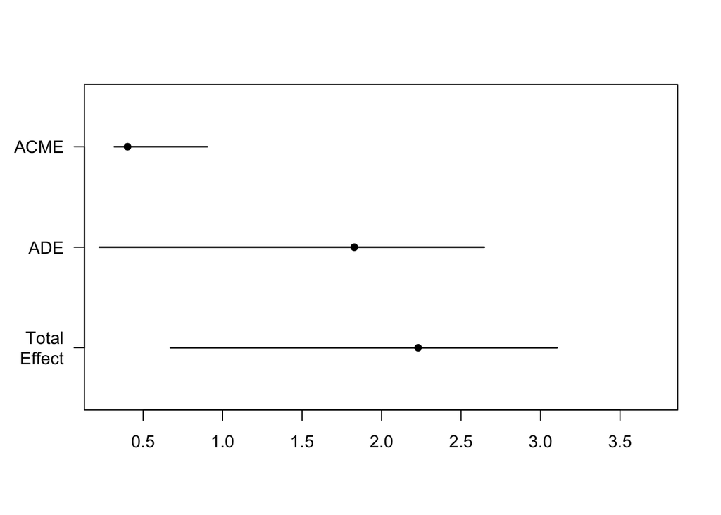

```r
plot(mediate_result)
```

```r
summary(mc)
```

```
##
## Call:
## lm(formula = BMI ~ RuralZIP_i + Gender3C + DEMO_Age_c + I(DEMO_Age_c^2) +
##     RaceC2 + aSES_02_z + PSS_z, data = data_to_measure)
##
## Residuals:
##     Min      1Q  Median      3Q     Max
## -15.009  -5.035  -1.331   4.310  36.640
##
## Coefficients:
##                                      Estimate Std. Error t value Pr(>|t|)
## (Intercept)                         2.726e+01  1.137e+00  23.978  < 2e-16 ***
## RuralZIP_i                          1.828e+00  6.113e-01   2.991 0.002897 **
## Gender3CMale                        8.964e-01  6.522e-01   1.374 0.169845
## DEMO_Age_c                          1.119e-02  1.678e-02   0.667 0.505073
## I(DEMO_Age_c^2)                    -1.181e-05  2.060e-05  -0.574 0.566502
## RaceC2HawaiianOtherPacificIslander  1.825e+00  1.999e+00   0.913 0.361549
## RaceC2HispanicAnyRace              -2.245e+00  1.661e+00  -1.351 0.177145
## RaceC2OtherRaceRaceNotReported     -5.123e-01  1.991e+00  -0.257 0.797006
## RaceC2WhiteOnly                     8.860e-01  1.146e+00   0.773 0.439808
## aSES_02_z                          -1.181e+00  3.055e-01  -3.865 0.000123 ***
## PSS_z                              -3.482e-01  3.173e-01  -1.097 0.272948
## ---
## Signif. codes:  0 '***' 0.001 '**' 0.01 '*' 0.05 '.' 0.1 ' ' 1
##
## Residual standard error: 7.219 on 602 degrees of freedom
##   (33 observations deleted due to missingness)
## Multiple R-squared:  0.0639, Adjusted R-squared:  0.04835
## F-statistic: 4.109 on 10 and 602 DF,  p-value: 1.687e-05
```

and in the nationwide HINTS dataset:

```r
set.seed(2708803)
#model is:
data_to_measure <- hines_cycle5 %>%
  filter( !is.na(HHInc_r) & !is.na(BMI) & Gender3C %in% c("Male","Female"))


#Rurality -> Income -> BMI
mb <- lm(HHInc_r~Age_c+I(Age_c^2)+Gender3C+HINTSIsRural_i+RacePP+filename+Fruit_vegetables_z,data_to_measure)
mc <- lm(BMI~Age_c+I(Age_c^2)+Gender3C+HINTSIsRural_i+RacePP+filename+Fruit_vegetables_z+HHInc_r,data_to_measure)

income_mediation <- mediate(mb,mc,sims=boot_times, boot=TRUE,boot.ci.type = "bca",
                            treat="HINTSIsRural_i",mediator="HHInc_r")
```

```
## Running nonparametric bootstrap
```

```r
summary(income_mediation)
```

```
##
## Causal Mediation Analysis
##
## Nonparametric Bootstrap Confidence Intervals with the BCa Method
##
##                Estimate 95% CI Lower 95% CI Upper p-value
## ACME              0.161        0.147         0.24  <2e-16 ***
## ADE               1.016        0.699         1.47  <2e-16 ***
## Total Effect      1.177        1.037         1.69  <2e-16 ***
## Prop. Mediated    0.137        0.116         0.21  <2e-16 ***
## ---
## Signif. codes:  0 '***' 0.001 '**' 0.01 '*' 0.05 '.' 0.1 ' ' 1
##
## Sample Size Used: 5999
##
##
## Simulations: 10
```

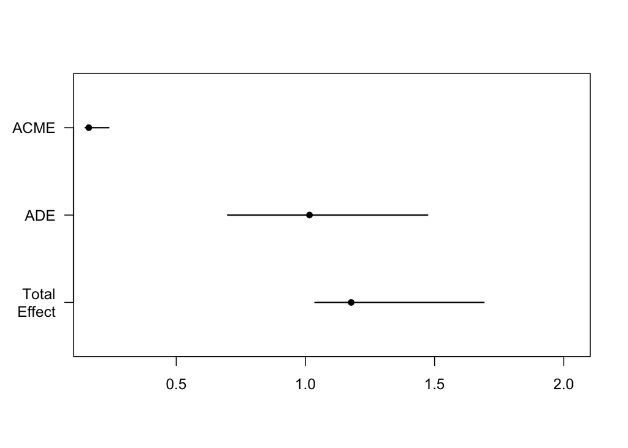

```r
plot(income_mediation)
```

```r
#lm(HHInc_r~BMIdata_to_measure$,data_to_measure$)
cor.test(data_to_measure$HHInc_r,as.numeric(data_to_measure$HINTSIsRural_i))
```

```
##
##  Pearson's product-moment correlation
##
## data:  data_to_measure$HHInc_r and as.numeric(data_to_measure$HINTSIsRural_i)
## t = -10.028, df = 13427, p-value < 2.2e-16
## alternative hypothesis: true correlation is not equal to 0
## 95 percent confidence interval:
##  -0.10298124 -0.06940564
## sample estimates:
##         cor
## -0.08621792
```

```r
summary(mc)
```

```
##
## Call:
## lm(formula = BMI ~ Age_c + I(Age_c^2) + Gender3C + HINTSIsRural_i +
##     RacePP + filename + Fruit_vegetables_z + HHInc_r, data = data_to_measure)
##
## Residuals:
##     Min      1Q  Median      3Q     Max
## -19.799  -4.173  -1.051   3.097  45.323
##
## Coefficients:
##                                          Estimate Std. Error t value Pr(>|t|)
## (Intercept)                            27.8515710  0.2033597 136.957  < 2e-16
## Age_c                                   0.1022310  0.0099619  10.262  < 2e-16
## I(Age_c^2)                             -0.0031267  0.0002722 -11.487  < 2e-16
## Gender3CMale                            0.0937142  0.1663531   0.563  0.57322
## HINTSIsRural_i                          1.0157033  0.2456261   4.135 3.60e-05
## RacePPBlack                             2.4303443  0.2386466  10.184  < 2e-16
## RacePPMissing data (Not Ascertained)    0.4775507  0.4266562   1.119  0.26306
## RacePPMultiple races selected           1.3675020  0.4308262   3.174  0.00151
## RacePPChinese                          -3.9484603  0.7257477  -5.441 5.52e-08
## RacePPFilipino                         -1.8940083  0.8139050  -2.327  0.02000
## RacePPAsian Indian                     -2.3877051  0.8594189  -2.778  0.00548
## RacePPOther Asian                      -3.1216985  1.0215655  -3.056  0.00225
## RacePPAmerican Indian or Alaska Native  0.4756276  1.0788634   0.441  0.65933
## RacePPPacific Islander                  0.6958076  1.1696942   0.595  0.55196
## RacePPVietnamese                       -5.5963128  1.1664635  -4.798 1.64e-06
## RacePPKorean                           -3.9351756  1.2550605  -3.135  0.00172
## RacePPJapanese                         -3.8660033  1.4394004  -2.686  0.00725
## filenamehints5_cycle3_public.sav        0.0651679  0.1846627   0.353  0.72417
## Fruit_vegetables_z                     -0.6389564  0.0835297  -7.649 2.34e-14
## HHInc_r                                -0.3802231  0.0572956  -6.636 3.50e-11
##
## (Intercept)                            ***
## Age_c                                  ***
## I(Age_c^2)                             ***
## Gender3CMale
## HINTSIsRural_i                         ***
## RacePPBlack                            ***
## RacePPMissing data (Not Ascertained)
## RacePPMultiple races selected          **
## RacePPChinese                          ***
## RacePPFilipino                         *
## RacePPAsian Indian                     **
## RacePPOther Asian                      **
## RacePPAmerican Indian or Alaska Native
## RacePPPacific Islander
## RacePPVietnamese                       ***
## RacePPKorean                           **
## RacePPJapanese                         **
## filenamehints5_cycle3_public.sav
## Fruit_vegetables_z                     ***
## HHInc_r                                ***
## ---
## Signif. codes:  0 '***' 0.001 '**' 0.01 '*' 0.05 '.' 0.1 ' ' 1
##
## Residual standard error: 6.255 on 5979 degrees of freedom
##   (7430 observations deleted due to missingness)
## Multiple R-squared:  0.08588,    Adjusted R-squared:  0.08297
## F-statistic: 29.56 on 19 and 5979 DF,  p-value: < 2.2e-16
```

### household income mediates the rurality-food availability relationship in the Oregon data

```r
library(mediation)
set.seed(45348321)
data_to_measure <- orfcs_dataset %>% filter(!is.na(MESA_healthyfoodavailability_z)) %>% filter(!is.na(MESA_healthyfoodavailability_z) & Gender3C %in% c("Male","Female"))

#Rurality -> Income -> BMI


mb <- lm(aSES_02_z~RuralZIP_i+Gender3C+DEMO_Age_c+I(DEMO_Age_c^2)+RaceC2+PSS_z
           #FFQ_cancer_preventing+FFQ_cancer_promoting+
           # IPAQ_total_METminutes+
           # MESA_neighborhoodconnectedness+
           # MESA_safetyfromcrime+
           # EDM_mean+
            # cancer_promoting_minus_preventing_liked_FCI+
            # cancer_promoting_minus_preventing_craved_FCI
         ,data_to_measure)
mc <- lm(MESA_healthyfoodavailability~RuralZIP_i+Gender3C+DEMO_Age_c+I(DEMO_Age_c^2)+RaceC2+aSES_02_z+PSS_z
           #FFQ_cancer_preventing+FFQ_cancer_promoting+
           # IPAQ_total_METminutes+
           # MESA_neighborhoodconnectedness+
           # MESA_safetyfromcrime+
           # EDM_mean+
            # cancer_promoting_minus_preventing_liked_FCI+
            # cancer_promoting_minus_preventing_craved_FCI
         ,data_to_measure)

mediate_result <- mediate(mb,mc,sims=boot_times,boot=TRUE,boot.ci.type = "bca",
                          treat="RuralZIP_i",mediator="aSES_02_z")
```

```
## Running nonparametric bootstrap
```

```r
summary(mediate_result)
```

```
##
## Causal Mediation Analysis
##
## Nonparametric Bootstrap Confidence Intervals with the BCa Method
##
##                Estimate 95% CI Lower 95% CI Upper p-value
## ACME            -0.0624      -0.1037        -0.04  <2e-16 ***
## ADE             -0.2302      -0.3568        -0.09  <2e-16 ***
## Total Effect    -0.2926      -0.4404        -0.14  <2e-16 ***
## Prop. Mediated   0.2132       0.1509         0.41  <2e-16 ***
## ---
## Signif. codes:  0 '***' 0.001 '**' 0.01 '*' 0.05 '.' 0.1 ' ' 1
##
## Sample Size Used: 714
##
##
## Simulations: 10
```

```r
summary(mc)
```

```
##
## Call:
## lm(formula = MESA_healthyfoodavailability ~ RuralZIP_i + Gender3C +
##     DEMO_Age_c + I(DEMO_Age_c^2) + RaceC2 + aSES_02_z + PSS_z,
##     data = data_to_measure)
##
## Residuals:
##      Min       1Q   Median       3Q      Max
## -3.11751 -0.46918  0.07322  0.64487  1.96407
##
## Coefficients:
##                                      Estimate Std. Error t value Pr(>|t|)
## (Intercept)                         4.181e+00  1.317e-01  31.746  < 2e-16 ***
## RuralZIP_i                         -2.302e-01  6.873e-02  -3.349 0.000853 ***
## Gender3CMale                       -1.518e-02  7.361e-02  -0.206 0.836680
## DEMO_Age_c                          5.394e-03  1.889e-03   2.855 0.004431 **
## I(DEMO_Age_c^2)                    -6.536e-06  2.357e-06  -2.773 0.005698 **
## RaceC2HawaiianOtherPacificIslander -2.320e-01  2.240e-01  -1.036 0.300731
## RaceC2HispanicAnyRace              -1.834e-01  1.871e-01  -0.980 0.327412
## RaceC2OtherRaceRaceNotReported     -5.316e-01  2.255e-01  -2.357 0.018702 *
## RaceC2WhiteOnly                    -3.212e-01  1.319e-01  -2.434 0.015172 *
## aSES_02_z                           1.809e-01  3.471e-02   5.213 2.44e-07 ***
## PSS_z                               4.981e-02  3.399e-02   1.466 0.143189
## ---
## Signif. codes:  0 '***' 0.001 '**' 0.01 '*' 0.05 '.' 0.1 ' ' 1
##
## Residual standard error: 0.8806 on 703 degrees of freedom
##   (49 observations deleted due to missingness)
## Multiple R-squared:  0.08383,    Adjusted R-squared:  0.07079
## F-statistic: 6.432 on 10 and 703 DF,  p-value: 1.584e-09
```

### The food availability mediation above disappears when controlling for income…

```r
set.seed(54948339)
data_to_measure <- orfcs_dataset %>% filter(!is.na(BMI)) %>% filter(!is.na(BMI) & Gender3C %in% c("Male","Female"))

#Rurality -> Income -> BMI
#

mb <- lm(MESA_healthyfoodavailability~RuralZIP_i+Gender3C+DEMO_Age_c+I(DEMO_Age_c^2)+RaceC2+
           aSES_02_z+PSS_z
           #FFQ_cancer_preventing+FFQ_cancer_promoting+
           # IPAQ_total_METminutes+
           # MESA_neighborhoodconnectedness+
           # MESA_safetyfromcrime+
           # EDM_mean+
            # cancer_promoting_minus_preventing_liked_FCI+
            # cancer_promoting_minus_preventing_craved_FCI
         ,data_to_measure)
mc <- lm(BMI~RuralZIP_i+Gender3C+DEMO_Age_c+I(DEMO_Age_c^2)+RaceC2+MESA_healthyfoodavailability_z+
           aSES_02_z+PSS_z
           #FFQ_cancer_preventing+FFQ_cancer_promoting+
           # IPAQ_total_METminutes+
           # MESA_neighborhoodconnectedness+
           # MESA_safetyfromcrime+
           # EDM_mean+
            # cancer_promoting_minus_preventing_liked_FCI+
            # cancer_promoting_minus_preventing_craved_FCI
         ,data_to_measure)

mediate_result <- mediate(mb,mc,sims=boot_times,boot=TRUE,boot.ci.type = "bca",
                          treat="RuralZIP_i",mediator="MESA_healthyfoodavailability_z")
```

```
## Running nonparametric bootstrap
```

```r
summary(mediate_result)
```

```
##
## Causal Mediation Analysis
##
## Nonparametric Bootstrap Confidence Intervals with the BCa Method
##
##                Estimate 95% CI Lower 95% CI Upper p-value
## ACME             0.1000      -0.0229         0.33     0.6
## ADE              1.7195       0.4032         2.80  <2e-16 ***
## Total Effect     1.8195       0.7100         2.77  <2e-16 ***
## Prop. Mediated   0.0550      -0.0101         0.49     0.6
## ---
## Signif. codes:  0 '***' 0.001 '**' 0.01 '*' 0.05 '.' 0.1 ' ' 1
##
## Sample Size Used: 613
##
##
## Simulations: 10
```

```r
summary(mc)
```

```
##
## Call:
## lm(formula = BMI ~ RuralZIP_i + Gender3C + DEMO_Age_c + I(DEMO_Age_c^2) +
##     RaceC2 + MESA_healthyfoodavailability_z + aSES_02_z + PSS_z,
##     data = data_to_measure)
##
## Residuals:
##     Min      1Q  Median      3Q     Max
## -14.944  -5.075  -1.285   4.331  36.211
##
## Coefficients:
##                                      Estimate Std. Error t value Pr(>|t|)
## (Intercept)                         2.747e+01  1.148e+00  23.931  < 2e-16 ***
## RuralZIP_i                          1.719e+00  6.167e-01   2.788 0.005470 **
## Gender3CMale                        8.777e-01  6.520e-01   1.346 0.178759
## DEMO_Age_c                          1.411e-02  1.692e-02   0.834 0.404688
## I(DEMO_Age_c^2)                    -1.527e-05  2.076e-05  -0.736 0.462108
## RaceC2HawaiianOtherPacificIslander  1.735e+00  1.999e+00   0.868 0.385694
## RaceC2HispanicAnyRace              -2.323e+00  1.661e+00  -1.398 0.162542
## RaceC2OtherRaceRaceNotReported     -7.666e-01  1.999e+00  -0.383 0.701515
## RaceC2WhiteOnly                     7.218e-01  1.152e+00   0.626 0.531311
## MESA_healthyfoodavailability_z     -3.954e-01  3.047e-01  -1.297 0.194962
## aSES_02_z                          -1.116e+00  3.094e-01  -3.606 0.000336 ***
## PSS_z                              -3.204e-01  3.178e-01  -1.008 0.313816
## ---
## Signif. codes:  0 '***' 0.001 '**' 0.01 '*' 0.05 '.' 0.1 ' ' 1
##
## Residual standard error: 7.215 on 601 degrees of freedom
##   (33 observations deleted due to missingness)
## Multiple R-squared:  0.06651,    Adjusted R-squared:  0.04943
## F-statistic: 3.893 on 11 and 601 DF,  p-value: 1.846e-05
```

### …and income mediates the relationship between food availability and BMI across the Oregon dataset

```r
set.seed(33527146)

data_to_measure <- orfcs_dataset %>% filter(!is.na(BMI)) %>% filter(!is.na(BMI) & Gender3C %in% c("Male","Female") & !is.na(PSS_z))

#Rurality -> Income -> BMI
#

mb <- lm(aSES_02_z~MESA_healthyfoodavailability_z+Gender3C+DEMO_Age_c+I(DEMO_Age_c^2)+RaceC2+PSS_z
         ,data_to_measure)
mc <- lm(BMI~MESA_healthyfoodavailability_z+Gender3C+DEMO_Age_c+I(DEMO_Age_c^2)+RaceC2+PSS_z+aSES_02_z
         ,data_to_measure)

mediate_result <- mediate(mb,mc,sims=boot_times,boot=TRUE,boot.ci.type = "bca",
                          treat="MESA_healthyfoodavailability_z",mediator="aSES_02_z")
```

```
## Running nonparametric bootstrap
```

```r
summary(mediate_result)
```

```
##
## Causal Mediation Analysis
##
## Nonparametric Bootstrap Confidence Intervals with the BCa Method
##
##                Estimate 95% CI Lower 95% CI Upper p-value
## ACME             -0.226       -0.246        -0.13  <2e-16 ***
## ADE              -0.563       -1.207        -0.18  <2e-16 ***
## Total Effect     -0.789       -1.400        -0.42  <2e-16 ***
## Prop. Mediated    0.286        0.121         0.56  <2e-16 ***
## ---
## Signif. codes:  0 '***' 0.001 '**' 0.01 '*' 0.05 '.' 0.1 ' ' 1
##
## Sample Size Used: 618
##
##
## Simulations: 10
```

```r
#summary(mb)
summary(mc)
```

```
##
## Call:
## lm(formula = BMI ~ MESA_healthyfoodavailability_z + Gender3C +
##     DEMO_Age_c + I(DEMO_Age_c^2) + RaceC2 + PSS_z + aSES_02_z,
##     data = data_to_measure)
##
## Residuals:
##     Min      1Q  Median      3Q     Max
## -14.149  -5.033  -1.349   4.271  35.344
##
## Coefficients:
##                                      Estimate Std. Error t value Pr(>|t|)
## (Intercept)                         2.828e+01  1.121e+00  25.228  < 2e-16 ***
## MESA_healthyfoodavailability_z     -5.634e-01  3.017e-01  -1.867   0.0623 .
## Gender3CMale                        6.823e-01  6.496e-01   1.050   0.2940
## DEMO_Age_c                          1.884e-02  1.690e-02   1.115   0.2655
## I(DEMO_Age_c^2)                    -2.119e-05  2.074e-05  -1.022   0.3073
## RaceC2HawaiianOtherPacificIslander  1.587e+00  2.008e+00   0.791   0.4294
## RaceC2HispanicAnyRace              -2.044e+00  1.666e+00  -1.227   0.2203
## RaceC2OtherRaceRaceNotReported     -8.841e-01  1.977e+00  -0.447   0.6548
## RaceC2WhiteOnly                     6.209e-01  1.157e+00   0.537   0.5917
## PSS_z                              -3.022e-01  3.180e-01  -0.950   0.3424
## aSES_02_z                          -1.217e+00  3.054e-01  -3.984 7.59e-05 ***
## ---
## Signif. codes:  0 '***' 0.001 '**' 0.01 '*' 0.05 '.' 0.1 ' ' 1
##
## Residual standard error: 7.249 on 607 degrees of freedom
##   (28 observations deleted due to missingness)
## Multiple R-squared:  0.05406,    Adjusted R-squared:  0.03847
## F-statistic: 3.469 on 10 and 607 DF,  p-value: 0.000188
```

## fruit consumption and healthy food availability

### Post-hoc: BMI-Fruit & Veggies relationship holds for the Oregon and HINTs datasets

#### Oregon

```r
predict_bmi_rural <- lm(BMI~FFQ_fruit_vegetables_z+
                    #MESA_healthyfoodavailability+MESA_safetyfromcrime
                      PSS_z+
                    DEMO_Age_c+I(DEMO_Age_c^2)+Gender3C+RaceC2,
                  orfcs_dataset)
summary(predict_bmi_rural)
```

```
##
## Call:
## lm(formula = BMI ~ FFQ_fruit_vegetables_z + PSS_z + DEMO_Age_c +
##     I(DEMO_Age_c^2) + Gender3C + RaceC2, data = orfcs_dataset)
##
## Residuals:
##     Min      1Q  Median      3Q     Max
## -14.500  -5.327  -0.926   4.152  35.795
##
## Coefficients:
##                                      Estimate Std. Error t value Pr(>|t|)
## (Intercept)                         2.837e+01  1.140e+00  24.898  < 2e-16 ***
## FFQ_fruit_vegetables_z             -1.079e+00  2.986e-01  -3.615 0.000325 ***
## PSS_z                              -3.075e-01  3.201e-01  -0.961 0.337154
## DEMO_Age_c                          1.273e-02  1.711e-02   0.744 0.457033
## I(DEMO_Age_c^2)                    -1.328e-05  2.104e-05  -0.631 0.528097
## Gender3CMale                        2.841e-01  6.524e-01   0.435 0.663357
## Gender3COther                       3.829e+00  2.868e+00   1.335 0.182366
## RaceC2HawaiianOtherPacificIslander  6.361e-01  2.019e+00   0.315 0.752850
## RaceC2HispanicAnyRace              -2.761e+00  1.670e+00  -1.654 0.098733 .
## RaceC2OtherRaceRaceNotReported     -1.652e+00  2.000e+00  -0.826 0.409151
## RaceC2WhiteOnly                     5.989e-01  1.177e+00   0.509 0.611204
## ---
## Signif. codes:  0 '***' 0.001 '**' 0.01 '*' 0.05 '.' 0.1 ' ' 1
##
## Residual standard error: 7.436 on 621 degrees of freedom
##   (218 observations deleted due to missingness)
## Multiple R-squared:  0.04228,    Adjusted R-squared:  0.02685
## F-statistic: 2.741 on 10 and 621 DF,  p-value: 0.002607
```

#### HINTS

```r
data_to_measure <- hines_cycle5


summary(lm(BMI~Age_c+Gender3C+RacePP+Fruit_vegetables_z,data_to_measure))
```

```
##
## Call:
## lm(formula = BMI ~ Age_c + Gender3C + RacePP + Fruit_vegetables_z,
##     data = data_to_measure)
##
## Residuals:
##     Min      1Q  Median      3Q     Max
## -19.206  -4.318  -1.113   3.126  47.437
##
## Coefficients:
##                                                         Estimate Std. Error
## (Intercept)                                            28.011487   0.144103
## Age_c                                                   0.006039   0.004685
## Gender3CMale                                            0.010846   0.161610
## Gender3CMissingOrMultiple                              -0.443349   0.346801
## RacePPBlack                                             2.922800   0.219255
## RacePPMissing data (Not Ascertained)                    0.639381   0.348449
## RacePPMultiple races selected                           1.699845   0.415088
## RacePPChinese                                          -4.417182   0.706623
## RacePPFilipino                                         -1.862009   0.810295
## RacePPAsian Indian                                     -2.992957   0.825290
## RacePPOther Asian                                      -3.119158   1.034055
## RacePPAmerican Indian or Alaska Native                  0.514454   1.032744
## RacePPPacific Islander                                  1.269091   1.160816
## RacePPVietnamese                                       -5.756028   1.124394
## RacePPMissing data (Web partial - Question Never Seen)  0.266815   1.270887
## RacePPKorean                                           -3.958168   1.223152
## RacePPJapanese                                         -4.033886   1.386595
## Fruit_vegetables_z                                     -0.706438   0.077434
##                                                        t value Pr(>|t|)
## (Intercept)                                            194.385  < 2e-16 ***
## Age_c                                                    1.289 0.197370
## Gender3CMale                                             0.067 0.946492
## Gender3CMissingOrMultiple                               -1.278 0.201153
## RacePPBlack                                             13.331  < 2e-16 ***
## RacePPMissing data (Not Ascertained)                     1.835 0.066559 .
## RacePPMultiple races selected                            4.095 4.27e-05 ***
## RacePPChinese                                           -6.251 4.32e-10 ***
## RacePPFilipino                                          -2.298 0.021595 *
## RacePPAsian Indian                                      -3.627 0.000289 ***
## RacePPOther Asian                                       -3.016 0.002567 **
## RacePPAmerican Indian or Alaska Native                   0.498 0.618400
## RacePPPacific Islander                                   1.093 0.274312
## RacePPVietnamese                                        -5.119 3.15e-07 ***
## RacePPMissing data (Web partial - Question Never Seen)   0.210 0.833718
## RacePPKorean                                            -3.236 0.001218 **
## RacePPJapanese                                          -2.909 0.003635 **
## Fruit_vegetables_z                                      -9.123  < 2e-16 ***
## ---
## Signif. codes:  0 '***' 0.001 '**' 0.01 '*' 0.05 '.' 0.1 ' ' 1
##
## Residual standard error: 6.337 on 6829 degrees of freedom
##   (9245 observations deleted due to missingness)
## Multiple R-squared:  0.05793,    Adjusted R-squared:  0.05558
## F-statistic:  24.7 on 17 and 6829 DF,  p-value: < 2.2e-16
```

```r
summary(lm(BMI~Age_c+I(Age_c^2)+Gender3C+RacePP+filename+Fruit_vegetables_z,data_to_measure))
```

```
##
## Call:
## lm(formula = BMI ~ Age_c + I(Age_c^2) + Gender3C + RacePP + filename +
##     Fruit_vegetables_z, data = data_to_measure)
##
## Residuals:
##     Min      1Q  Median      3Q     Max
## -19.078  -4.197  -1.090   3.080  47.238
##
## Coefficients:
##                                                          Estimate Std. Error
## (Intercept)                                            28.1241305  0.1898487
## Age_c                                                   0.1006340  0.0093590
## I(Age_c^2)                                             -0.0028553  0.0002456
## Gender3CMale                                           -0.0683317  0.1601906
## Gender3CMissingOrMultiple                              -0.2748698  0.3438440
## RacePPBlack                                             2.7467309  0.2176623
## RacePPMissing data (Not Ascertained)                    0.6747714  0.3452032
## RacePPMultiple races selected                           1.6550879  0.4111013
## RacePPChinese                                          -4.1049979  0.7003824
## RacePPFilipino                                         -1.9830342  0.8025344
## RacePPAsian Indian                                     -2.8002267  0.8175722
## RacePPOther Asian                                      -3.0897230  1.0240536
## RacePPAmerican Indian or Alaska Native                  0.6033645  1.0228213
## RacePPPacific Islander                                  1.0060023  1.1500064
## RacePPVietnamese                                       -5.8534201  1.1136641
## RacePPMissing data (Web partial - Question Never Seen)  0.4310170  1.2592174
## RacePPKorean                                           -4.1055617  1.2114120
## RacePPJapanese                                         -4.0830311  1.3731879
## filenamehints5_cycle3_public.sav                       -0.0767315  0.1740263
## Fruit_vegetables_z                                     -0.7220771  0.0770957
##                                                        t value Pr(>|t|)
## (Intercept)                                            148.140  < 2e-16 ***
## Age_c                                                   10.753  < 2e-16 ***
## I(Age_c^2)                                             -11.625  < 2e-16 ***
## Gender3CMale                                            -0.427 0.669709
## Gender3CMissingOrMultiple                               -0.799 0.424085
## RacePPBlack                                             12.619  < 2e-16 ***
## RacePPMissing data (Not Ascertained)                     1.955 0.050658 .
## RacePPMultiple races selected                            4.026 5.74e-05 ***
## RacePPChinese                                           -5.861 4.81e-09 ***
## RacePPFilipino                                          -2.471 0.013499 *
## RacePPAsian Indian                                      -3.425 0.000618 ***
## RacePPOther Asian                                       -3.017 0.002561 **
## RacePPAmerican Indian or Alaska Native                   0.590 0.555276
## RacePPPacific Islander                                   0.875 0.381725
## RacePPVietnamese                                        -5.256 1.52e-07 ***
## RacePPMissing data (Web partial - Question Never Seen)   0.342 0.732144
## RacePPKorean                                            -3.389 0.000705 ***
## RacePPJapanese                                          -2.973 0.002956 **
## filenamehints5_cycle3_public.sav                        -0.441 0.659286
## Fruit_vegetables_z                                      -9.366  < 2e-16 ***
## ---
## Signif. codes:  0 '***' 0.001 '**' 0.01 '*' 0.05 '.' 0.1 ' ' 1
##
## Residual standard error: 6.276 on 6827 degrees of freedom
##   (9245 observations deleted due to missingness)
## Multiple R-squared:  0.07634,    Adjusted R-squared:  0.07377
## F-statistic:  29.7 on 19 and 6827 DF,  p-value: < 2.2e-16
```

```r
summary(lm(BMI~Age_c+I(Age_c^2)+Gender3C+RacePP+filename+Fruit_vegetables_z+I(Fruit_vegetables_z^2),data_to_measure))
```

```
##
## Call:
## lm(formula = BMI ~ Age_c + I(Age_c^2) + Gender3C + RacePP + filename +
##     Fruit_vegetables_z + I(Fruit_vegetables_z^2), data = data_to_measure)
##
## Residuals:
##     Min      1Q  Median      3Q     Max
## -19.081  -4.203  -1.095   3.083  47.223
##
## Coefficients:
##                                                          Estimate Std. Error
## (Intercept)                                            28.1400000  0.2008234
## Age_c                                                   0.1006398  0.0093597
## I(Age_c^2)                                             -0.0028560  0.0002457
## Gender3CMale                                           -0.0671374  0.1602773
## Gender3CMissingOrMultiple                              -0.2751152  0.3438692
## RacePPBlack                                             2.7491203  0.2179002
## RacePPMissing data (Not Ascertained)                    0.6750428  0.3452288
## RacePPMultiple races selected                           1.6572773  0.4112288
## RacePPChinese                                          -4.1029981  0.7004792
## RacePPFilipino                                         -1.9831178  0.8025898
## RacePPAsian Indian                                     -2.8016597  0.8176499
## RacePPOther Asian                                      -3.0884738  1.0241371
## RacePPAmerican Indian or Alaska Native                  0.6071715  1.0230122
## RacePPPacific Islander                                  1.0030844  1.1501486
## RacePPVietnamese                                       -5.8487853  1.1139049
## RacePPMissing data (Web partial - Question Never Seen)  0.4335405  1.2593472
## RacePPKorean                                           -4.1060818  1.2114974
## RacePPJapanese                                         -4.0724153  1.3739802
## filenamehints5_cycle3_public.sav                       -0.0803750  0.1746856
## Fruit_vegetables_z                                     -0.7212140  0.0771831
## I(Fruit_vegetables_z^2)                                -0.0140105  0.0577750
##                                                        t value Pr(>|t|)
## (Intercept)                                            140.123  < 2e-16 ***
## Age_c                                                   10.752  < 2e-16 ***
## I(Age_c^2)                                             -11.626  < 2e-16 ***
## Gender3CMale                                            -0.419 0.675315
## Gender3CMissingOrMultiple                               -0.800 0.423705
## RacePPBlack                                             12.616  < 2e-16 ***
## RacePPMissing data (Not Ascertained)                     1.955 0.050583 .
## RacePPMultiple races selected                            4.030 5.64e-05 ***
## RacePPChinese                                           -5.857 4.92e-09 ***
## RacePPFilipino                                          -2.471 0.013502 *
## RacePPAsian Indian                                      -3.426 0.000615 ***
## RacePPOther Asian                                       -3.016 0.002573 **
## RacePPAmerican Indian or Alaska Native                   0.594 0.552857
## RacePPPacific Islander                                   0.872 0.383166
## RacePPVietnamese                                        -5.251 1.56e-07 ***
## RacePPMissing data (Web partial - Question Never Seen)   0.344 0.730663
## RacePPKorean                                            -3.389 0.000705 ***
## RacePPJapanese                                          -2.964 0.003048 **
## filenamehints5_cycle3_public.sav                        -0.460 0.645450
## Fruit_vegetables_z                                      -9.344  < 2e-16 ***
## I(Fruit_vegetables_z^2)                                 -0.243 0.808399
## ---
## Signif. codes:  0 '***' 0.001 '**' 0.01 '*' 0.05 '.' 0.1 ' ' 1
##
## Residual standard error: 6.276 on 6826 degrees of freedom
##   (9245 observations deleted due to missingness)
## Multiple R-squared:  0.07635,    Adjusted R-squared:  0.07364
## F-statistic: 28.21 on 20 and 6826 DF,  p-value: < 2.2e-16
```

### Fruit (and vegetable???) consumption mediates the relationship between healthy food availability and BMI

#### Oregon

```r
set.seed(25296177)

data_to_measure <- orfcs_dataset %>% filter(!is.na(BMI) & !is.na(MESA_healthyfoodavailability_z) & !is.na(FFQ_fruit_vegetables_z) & !is.na(RuralZIP) &Gender3C %in% c("Female", "Male"))

# treatment MESA_healthyfoodavailability
# mediator FFQ_fruits_ln_z

mb <- lm(FFQ_fruit_vegetables_z~MESA_healthyfoodavailability_z+Gender3C+DEMO_Age_c+I(DEMO_Age_c^2)+RaceC2,data_to_measure)
mc <- lm(BMI~            MESA_healthyfoodavailability_z+Gender3C+DEMO_Age_c+I(DEMO_Age_c^2)+RaceC2+FFQ_fruit_vegetables_z,data_to_measure)

mediate_result <- mediate(mb,mc,sims=boot_times,boot=TRUE,boot.ci.type = "bca",
                          treat="MESA_healthyfoodavailability_z",mediator="FFQ_fruit_vegetables_z")
```

```
## Running nonparametric bootstrap
```

```r
summary(mediate_result)
```

```
##
## Causal Mediation Analysis
##
## Nonparametric Bootstrap Confidence Intervals with the BCa Method
##
##                Estimate 95% CI Lower 95% CI Upper p-value
## ACME             -0.142       -0.201        -0.09  <2e-16 ***
## ADE              -0.647       -1.188        -0.39     0.2
## Total Effect     -0.789       -1.308        -0.22  <2e-16 ***
## Prop. Mediated    0.180        0.184         2.79  <2e-16 ***
## ---
## Signif. codes:  0 '***' 0.001 '**' 0.01 '*' 0.05 '.' 0.1 ' ' 1
##
## Sample Size Used: 620
##
##
## Simulations: 10
```

```r
summary(mb)
```

```
##
## Call:
## lm(formula = FFQ_fruit_vegetables_z ~ MESA_healthyfoodavailability_z +
##     Gender3C + DEMO_Age_c + I(DEMO_Age_c^2) + RaceC2, data = data_to_measure)
##
## Residuals:
##      Min       1Q   Median       3Q      Max
## -2.46267 -0.73446 -0.06556  0.68068  2.73768
##
## Coefficients:
##                                      Estimate Std. Error t value Pr(>|t|)
## (Intercept)                        -1.045e-01  1.521e-01  -0.687 0.492300
## MESA_healthyfoodavailability_z      1.501e-01  4.056e-02   3.700 0.000235 ***
## Gender3CMale                        6.638e-02  8.729e-02   0.761 0.447235
## DEMO_Age_c                         -2.942e-03  2.254e-03  -1.305 0.192283
## I(DEMO_Age_c^2)                     4.391e-06  2.774e-06   1.583 0.113969
## RaceC2HawaiianOtherPacificIslander  3.850e-01  2.688e-01   1.432 0.152592
## RaceC2HispanicAnyRace               4.404e-02  2.247e-01   0.196 0.844649
## RaceC2OtherRaceRaceNotReported      7.586e-02  2.682e-01   0.283 0.777360
## RaceC2WhiteOnly                     5.780e-02  1.570e-01   0.368 0.712960
## ---
## Signif. codes:  0 '***' 0.001 '**' 0.01 '*' 0.05 '.' 0.1 ' ' 1
##
## Residual standard error: 0.9914 on 611 degrees of freedom
##   (21 observations deleted due to missingness)
## Multiple R-squared:  0.03025,    Adjusted R-squared:  0.01756
## F-statistic: 2.383 on 8 and 611 DF,  p-value: 0.01561
```

```r
summary(mc)
```

```
##
## Call:
## lm(formula = BMI ~ MESA_healthyfoodavailability_z + Gender3C +
##     DEMO_Age_c + I(DEMO_Age_c^2) + RaceC2 + FFQ_fruit_vegetables_z,
##     data = data_to_measure)
##
## Residuals:
##     Min      1Q  Median      3Q     Max
## -14.348  -5.288  -0.943   3.912  35.139
##
## Coefficients:
##                                      Estimate Std. Error t value Pr(>|t|)
## (Intercept)                         2.867e+01  1.119e+00  25.621  < 2e-16 ***
## MESA_healthyfoodavailability_z     -6.468e-01  3.017e-01  -2.144  0.03245 *
## Gender3CMale                        4.095e-01  6.424e-01   0.637  0.52409
## DEMO_Age_c                          1.887e-02  1.660e-02   1.136  0.25627
## I(DEMO_Age_c^2)                    -2.067e-05  2.045e-05  -1.011  0.31243
## RaceC2HawaiianOtherPacificIslander  4.583e-01  1.981e+00   0.231  0.81711
## RaceC2HispanicAnyRace              -2.528e+00  1.653e+00  -1.530  0.12657
## RaceC2OtherRaceRaceNotReported     -2.377e+00  1.973e+00  -1.205  0.22864
## RaceC2WhiteOnly                     2.594e-01  1.155e+00   0.224  0.82245
## FFQ_fruit_vegetables_z             -9.446e-01  2.976e-01  -3.174  0.00158 **
## ---
## Signif. codes:  0 '***' 0.001 '**' 0.01 '*' 0.05 '.' 0.1 ' ' 1
##
## Residual standard error: 7.293 on 610 degrees of freedom
##   (21 observations deleted due to missingness)
## Multiple R-squared:  0.04288,    Adjusted R-squared:  0.02876
## F-statistic: 3.037 on 9 and 610 DF,  p-value: 0.00146
```

#### HINTS

```r
set.seed(96734053)
data_to_measure <- hines_cycle5 %>%
  filter(!is.na(HHInc_r) & !is.na(BMI) & !is.na(Fruit_vegetables_z))


#Rurality -> Income -> BMI
mb <- lm(Fruit_vegetables_z~Age_c+I(Age_c^2)+HINTSIsRural_i+RacePP+filename+HHInc_r,data_to_measure)
mc <- lm(BMI~Age_c+I(Age_c^2)+HINTSIsRural_i+RacePP+filename+HHInc_r+Fruit_vegetables_z,data_to_measure)

vegetables_mediation <- mediate(mb,mc,sims=boot_times, boot=TRUE,boot.ci.type = "bca",
                                treat="HINTSIsRural_i",mediator="Fruit_vegetables_z")
```

```
## Running nonparametric bootstrap
```

```r
summary(vegetables_mediation)
```

```
##
## Causal Mediation Analysis
##
## Nonparametric Bootstrap Confidence Intervals with the BCa Method
##
##                Estimate 95% CI Lower 95% CI Upper p-value
## ACME             0.0502       0.0138         0.08  <2e-16 ***
## ADE              0.9558       0.5458         1.28  <2e-16 ***
## Total Effect     1.0060       0.5923         1.36  <2e-16 ***
## Prop. Mediated   0.0499       0.0181         0.10  <2e-16 ***
## ---
## Signif. codes:  0 '***' 0.001 '**' 0.01 '*' 0.05 '.' 0.1 ' ' 1
##
## Sample Size Used: 6231
##
##
## Simulations: 10
```

```r
summary(mc)
```

```
##
## Call:
## lm(formula = BMI ~ Age_c + I(Age_c^2) + HINTSIsRural_i + RacePP +
##     filename + HHInc_r + Fruit_vegetables_z, data = data_to_measure)
##
## Residuals:
##     Min      1Q  Median      3Q     Max
## -19.729  -4.166  -1.066   3.116  45.339
##
## Coefficients:
##                                          Estimate Std. Error t value Pr(>|t|)
## (Intercept)                            27.8985206  0.1881182 148.303  < 2e-16
## Age_c                                   0.1029345  0.0097477  10.560  < 2e-16
## I(Age_c^2)                             -0.0031441  0.0002655 -11.844  < 2e-16
## HINTSIsRural_i                          0.9558242  0.2412478   3.962 7.52e-05
## RacePPBlack                             2.4612835  0.2324209  10.590  < 2e-16
## RacePPMissing data (Not Ascertained)    0.6159502  0.4128311   1.492 0.135746
## RacePPMultiple races selected           1.4937156  0.4245994   3.518 0.000438
## RacePPChinese                          -3.9535660  0.7078213  -5.586 2.43e-08
## RacePPFilipino                         -1.8931000  0.8141081  -2.325 0.020084
## RacePPAsian Indian                     -2.4351747  0.8366584  -2.911 0.003620
## RacePPOther Asian                      -3.1027473  1.0218307  -3.036 0.002404
## RacePPAmerican Indian or Alaska Native  0.1454411  1.0346549   0.141 0.888214
## RacePPPacific Islander                  0.5851038  1.1504274   0.509 0.611053
## RacePPVietnamese                       -5.6706419  1.1474782  -4.942 7.94e-07
## RacePPKorean                           -4.0380622  1.2085574  -3.341 0.000839
## RacePPJapanese                         -3.9385899  1.4035236  -2.806 0.005028
## filenamehints5_cycle3_public.sav        0.0491558  0.1813458   0.271 0.786353
## HHInc_r                                -0.3785171  0.0554973  -6.820 9.93e-12
## Fruit_vegetables_z                     -0.6355544  0.0816732  -7.782 8.33e-15
##
## (Intercept)                            ***
## Age_c                                  ***
## I(Age_c^2)                             ***
## HINTSIsRural_i                         ***
## RacePPBlack                            ***
## RacePPMissing data (Not Ascertained)
## RacePPMultiple races selected          ***
## RacePPChinese                          ***
## RacePPFilipino                         *
## RacePPAsian Indian                     **
## RacePPOther Asian                      **
## RacePPAmerican Indian or Alaska Native
## RacePPPacific Islander
## RacePPVietnamese                       ***
## RacePPKorean                           ***
## RacePPJapanese                         **
## filenamehints5_cycle3_public.sav
## HHInc_r                                ***
## Fruit_vegetables_z                     ***
## ---
## Signif. codes:  0 '***' 0.001 '**' 0.01 '*' 0.05 '.' 0.1 ' ' 1
##
## Residual standard error: 6.259 on 6212 degrees of freedom
##   (93 observations deleted due to missingness)
## Multiple R-squared:  0.0876, Adjusted R-squared:  0.08496
## F-statistic: 33.14 on 18 and 6212 DF,  p-value: < 2.2e-16
```

## fruit consumption and rurality (mainly interesting as a general proxy for healthy eating)

```r
set.seed(70213575)

#Rurality -> Income -> BMI
mb <- lm(Fruit_vegetables_z~Age_c+I(Age_c^2)+HINTSIsRural_i+RacePP+filename+HHInc_r,data_to_measure)
mc <- lm(BMI~Age_c+I(Age_c^2)+HINTSIsRural_i+RacePP+filename+HHInc_r+Fruit_vegetables_z,data_to_measure)

fruit_mediation <- mediate(mb,mc,sims=boot_times, boot=TRUE,boot.ci.type = "bca",
                           treat="HINTSIsRural_i",mediator="Fruit_vegetables_z")
```

```
## Running nonparametric bootstrap
```

```r
summary(fruit_mediation)
```

```
##
## Causal Mediation Analysis
##
## Nonparametric Bootstrap Confidence Intervals with the BCa Method
##
##                Estimate 95% CI Lower 95% CI Upper p-value
## ACME            0.05018     -0.00439         0.12     0.2
## ADE             0.95582      0.52619         1.04  <2e-16 ***
## Total Effect    1.00600      0.52812         1.08  <2e-16 ***
## Prop. Mediated  0.04988     -0.01143         0.10     0.2
## ---
## Signif. codes:  0 '***' 0.001 '**' 0.01 '*' 0.05 '.' 0.1 ' ' 1
##
## Sample Size Used: 6231
##
##
## Simulations: 10
```

```r
summary(mc)
```

```
##
## Call:
## lm(formula = BMI ~ Age_c + I(Age_c^2) + HINTSIsRural_i + RacePP +
##     filename + HHInc_r + Fruit_vegetables_z, data = data_to_measure)
##
## Residuals:
##     Min      1Q  Median      3Q     Max
## -19.729  -4.166  -1.066   3.116  45.339
##
## Coefficients:
##                                          Estimate Std. Error t value Pr(>|t|)
## (Intercept)                            27.8985206  0.1881182 148.303  < 2e-16
## Age_c                                   0.1029345  0.0097477  10.560  < 2e-16
## I(Age_c^2)                             -0.0031441  0.0002655 -11.844  < 2e-16
## HINTSIsRural_i                          0.9558242  0.2412478   3.962 7.52e-05
## RacePPBlack                             2.4612835  0.2324209  10.590  < 2e-16
## RacePPMissing data (Not Ascertained)    0.6159502  0.4128311   1.492 0.135746
## RacePPMultiple races selected           1.4937156  0.4245994   3.518 0.000438
## RacePPChinese                          -3.9535660  0.7078213  -5.586 2.43e-08
## RacePPFilipino                         -1.8931000  0.8141081  -2.325 0.020084
## RacePPAsian Indian                     -2.4351747  0.8366584  -2.911 0.003620
## RacePPOther Asian                      -3.1027473  1.0218307  -3.036 0.002404
## RacePPAmerican Indian or Alaska Native  0.1454411  1.0346549   0.141 0.888214
## RacePPPacific Islander                  0.5851038  1.1504274   0.509 0.611053
## RacePPVietnamese                       -5.6706419  1.1474782  -4.942 7.94e-07
## RacePPKorean                           -4.0380622  1.2085574  -3.341 0.000839
## RacePPJapanese                         -3.9385899  1.4035236  -2.806 0.005028
## filenamehints5_cycle3_public.sav        0.0491558  0.1813458   0.271 0.786353
## HHInc_r                                -0.3785171  0.0554973  -6.820 9.93e-12
## Fruit_vegetables_z                     -0.6355544  0.0816732  -7.782 8.33e-15
##
## (Intercept)                            ***
## Age_c                                  ***
## I(Age_c^2)                             ***
## HINTSIsRural_i                         ***
## RacePPBlack                            ***
## RacePPMissing data (Not Ascertained)
## RacePPMultiple races selected          ***
## RacePPChinese                          ***
## RacePPFilipino                         *
## RacePPAsian Indian                     **
## RacePPOther Asian                      **
## RacePPAmerican Indian or Alaska Native
## RacePPPacific Islander
## RacePPVietnamese                       ***
## RacePPKorean                           ***
## RacePPJapanese                         **
## filenamehints5_cycle3_public.sav
## HHInc_r                                ***
## Fruit_vegetables_z                     ***
## ---
## Signif. codes:  0 '***' 0.001 '**' 0.01 '*' 0.05 '.' 0.1 ' ' 1
##
## Residual standard error: 6.259 on 6212 degrees of freedom
##   (93 observations deleted due to missingness)
## Multiple R-squared:  0.0876, Adjusted R-squared:  0.08496
## F-statistic: 33.14 on 18 and 6212 DF,  p-value: < 2.2e-16
```

```r
set.seed(30567291)

data_to_measure <- orfcs_dataset %>% filter(!is.na(BMI) & !is.na(MESA_healthyfoodavailability_z) & !is.na(FFQ_fruit_vegetables_z) & !is.na(RuralZIP_i) & Gender3C %in% c("Female", "Male"))



mb <- lm(FFQ_fruit_vegetables_z~RuralZIP_i+MESA_healthyfoodavailability_z+Gender3C+DEMO_Age_c+I(DEMO_Age_c^2)+RaceC2+PSS_z,data_to_measure)
mc <- lm(BMI~            RuralZIP_i+MESA_healthyfoodavailability_z+Gender3C+DEMO_Age_c+I(DEMO_Age_c^2)+RaceC2+PSS_z+FFQ_fruit_vegetables_z,data_to_measure)

mediate_result <- mediate(mb,mc,sims=boot_times, boot=TRUE,boot.ci.type = "bca",
                          treat="RuralZIP_i",mediator="FFQ_fruit_vegetables_z")
```

```
## Running nonparametric bootstrap
```

```r
summary(mediate_result)
```

```
##
## Causal Mediation Analysis
##
## Nonparametric Bootstrap Confidence Intervals with the BCa Method
##
##                Estimate 95% CI Lower 95% CI Upper p-value
## ACME            -0.0904      -0.2470         0.06       1
## ADE              2.1172       0.8831         2.69  <2e-16 ***
## Total Effect     2.0268       0.8240         2.69  <2e-16 ***
## Prop. Mediated  -0.0446      -0.1665         0.03       1
## ---
## Signif. codes:  0 '***' 0.001 '**' 0.01 '*' 0.05 '.' 0.1 ' ' 1
##
## Sample Size Used: 620
##
##
## Simulations: 10
```

```r
summary(mb)
```

```
##
## Call:
## lm(formula = FFQ_fruit_vegetables_z ~ RuralZIP_i + MESA_healthyfoodavailability_z +
##     Gender3C + DEMO_Age_c + I(DEMO_Age_c^2) + RaceC2 + PSS_z,
##     data = data_to_measure)
##
## Residuals:
##      Min       1Q   Median       3Q      Max
## -2.62452 -0.72656 -0.05685  0.69090  2.71072
##
## Coefficients:
##                                      Estimate Std. Error t value Pr(>|t|)
## (Intercept)                        -1.292e-01  1.574e-01  -0.821 0.411947
## RuralZIP_i                          9.312e-02  8.350e-02   1.115 0.265223
## MESA_healthyfoodavailability_z      1.535e-01  4.123e-02   3.724 0.000214 ***
## Gender3CMale                        8.059e-02  8.765e-02   0.919 0.358240
## DEMO_Age_c                         -2.429e-03  2.314e-03  -1.050 0.294300
## I(DEMO_Age_c^2)                     3.834e-06  2.840e-06   1.350 0.177583
## RaceC2HawaiianOtherPacificIslander  3.905e-01  2.690e-01   1.452 0.147100
## RaceC2HispanicAnyRace               6.328e-03  2.257e-01   0.028 0.977640
## RaceC2OtherRaceRaceNotReported      3.380e-02  2.714e-01   0.125 0.900953
## RaceC2WhiteOnly                     4.272e-02  1.578e-01   0.271 0.786637
## PSS_z                               5.541e-02  4.320e-02   1.283 0.200068
## ---
## Signif. codes:  0 '***' 0.001 '**' 0.01 '*' 0.05 '.' 0.1 ' ' 1
##
## Residual standard error: 0.9907 on 609 degrees of freedom
##   (21 observations deleted due to missingness)
## Multiple R-squared:  0.03472,    Adjusted R-squared:  0.01887
## F-statistic:  2.19 on 10 and 609 DF,  p-value: 0.01694
```

```r
summary(mc)
```

```
##
## Call:
## lm(formula = BMI ~ RuralZIP_i + MESA_healthyfoodavailability_z +
##     Gender3C + DEMO_Age_c + I(DEMO_Age_c^2) + RaceC2 + PSS_z +
##     FFQ_fruit_vegetables_z, data = data_to_measure)
##
## Residuals:
##     Min      1Q  Median      3Q     Max
## -14.541  -5.027  -1.160   4.062  36.281
##
## Coefficients:
##                                      Estimate Std. Error t value Pr(>|t|)
## (Intercept)                         2.756e+01  1.148e+00  24.010  < 2e-16 ***
## RuralZIP_i                          2.117e+00  6.094e-01   3.475 0.000548 ***
## MESA_healthyfoodavailability_z     -4.396e-01  3.040e-01  -1.446 0.148579
## Gender3CMale                        5.341e-01  6.395e-01   0.835 0.403876
## DEMO_Age_c                          1.076e-02  1.688e-02   0.637 0.524346
## I(DEMO_Age_c^2)                    -1.049e-05  2.074e-05  -0.506 0.613335
## RaceC2HawaiianOtherPacificIslander  8.260e-01  1.964e+00   0.421 0.674237
## RaceC2HispanicAnyRace              -2.605e+00  1.645e+00  -1.583 0.113911
## RaceC2OtherRaceRaceNotReported     -1.722e+00  1.979e+00  -0.870 0.384553
## RaceC2WhiteOnly                     5.125e-01  1.150e+00   0.446 0.656033
## PSS_z                              -3.906e-01  3.153e-01  -1.239 0.215911
## FFQ_fruit_vegetables_z             -9.709e-01  2.954e-01  -3.286 0.001073 **
## ---
## Signif. codes:  0 '***' 0.001 '**' 0.01 '*' 0.05 '.' 0.1 ' ' 1
##
## Residual standard error: 7.223 on 608 degrees of freedom
##   (21 observations deleted due to missingness)
## Multiple R-squared:  0.06423,    Adjusted R-squared:  0.0473
## F-statistic: 3.794 on 11 and 608 DF,  p-value: 2.761e-05
```

## Linear model of everything we’ve tested here including demographics not usually measured

```r
orfcs_dataset$HHIncome_z <- zscore(orfcs_dataset$aSES_02_z)
orfcs_dataset$ZipcodeMedianHouseholdIncome_z <- zscore(orfcs_dataset$ZipcodeMedianHouseholdIncome)
orfcs_dataset$IPAQ_total_METminutes_z <- zscore(orfcs_dataset$IPAQ_total_METminutes)
orfcs_comprehensive_model <- lm(BMI~DEMO_Age_c+I(DEMO_Age_c^2)+Gender3C+RaceC2+PSS_z
    +Education_Ordinal
   +RuralZIP_i
   +MESA_healthyfoodavailability_z+MESA_safetyfromcrime
   +FFQ_fruit_vegetables_z
   +IPAQ_total_METminutes_z
   +ZipcodeMedianHouseholdIncome_z
   +HHIncome_z,orfcs_dataset)
library(apaTables)

apa.reg.table(orfcs_comprehensive_model)
```

```
##
##
## Regression results using BMI as the criterion
##
##
##                           Predictor       b       b_95%_CI sr2  sr2_95%_CI
##                         (Intercept) 28.68** [25.32, 32.03]
##                          DEMO_Age_c    0.01  [-0.02, 0.05] .00 [-.00, .00]
##                     I(DEMO_Age_c^2)   -0.00  [-0.00, 0.00] .00 [-.00, .00]
##                        Gender3CMale    1.09  [-0.24, 2.41] .00 [-.01, .01]
##                       Gender3COther   7.72*  [1.20, 14.23] .01 [-.01, .02]
##  RaceC2HawaiianOtherPacificIslander    2.45  [-1.63, 6.54] .00 [-.00, .01]
##               RaceC2HispanicAnyRace   -2.62  [-5.94, 0.69] .00 [-.01, .01]
##      RaceC2OtherRaceRaceNotReported   -0.64  [-4.65, 3.37] .00 [-.00, .00]
##                     RaceC2WhiteOnly    0.97  [-1.35, 3.29] .00 [-.00, .01]
##                               PSS_z   -0.15  [-0.78, 0.48] .00 [-.00, .00]
##                   Education_Ordinal   -0.02  [-0.32, 0.29] .00 [-.00, .00]
##                          RuralZIP_i   1.75*   [0.36, 3.13] .01 [-.01, .02]
##      MESA_healthyfoodavailability_z   -0.25  [-0.89, 0.40] .00 [-.00, .01]
##                MESA_safetyfromcrime   -0.42  [-1.04, 0.21] .00 [-.01, .01]
##              FFQ_fruit_vegetables_z -0.83** [-1.43, -0.23] .01 [-.00, .03]
##             IPAQ_total_METminutes_z   -0.51  [-1.20, 0.18] .00 [-.01, .01]
##      ZipcodeMedianHouseholdIncome_z    0.02  [-0.66, 0.69] .00 [-.00, .00]
##                          HHIncome_z -0.97** [-1.61, -0.33] .01 [-.00, .03]
##
##
##
##              Fit
##
##
##
##
##
##
##
##
##
##
##
##
##
##
##
##
##
##
##      R2 = .087**
##  95% CI[.03,.11]
##
##
## Note. A significant b-weight indicates the semi-partial correlation is also significant.
## b represents unstandardized regression weights.
## sr2 represents the semi-partial correlation squared.
## Square brackets are used to enclose the lower and upper limits of a confidence interval.
## * indicates p < .05. ** indicates p < .01.
##
```

```r
table(hines_cycle5$Education)
```

```
##
##                               Missing data (Not Ascertained)
##                                                          412
##                                            Less than 8 years
##                                                          282
##                                           8 through 11 years
##                                                          817
##                            12 years or completed high school
##                                                         2898
## Post high school training other than college (vocational or
##                                                         1113
##                                                 Some college
##                                                         3540
##                                             College graduate
##                                                         4119
##                                                 Postgraduate
##                                                         2868
##             Missing data (Web partial - Question Never Seen)
##                                                           43
```

```r
hines_cycle5$EducationalAchievement<-as.integer(hines_cycle5$EducationOrdinal)

# orfcs_dataset$HHIncome_z <- zscore(orfcs_dataset$aSES_02_z)
hines_cycle5$HHInc_r_z <- zscore(hines_cycle5$HHInc_r)
HINTS_comprehensive_model <- lm(BMI~Age_c+I(Age_c^2)+Gender3C+RacePP
    +EducationalAchievement
   +HINTSIsRural_i
   +Fruit_vegetables_z
   +filename
   +HHInc_r_z,hines_cycle5)
library(apaTables)

hints_bmi_table<-apa.reg.table(HINTS_comprehensive_model)
#apa.reg.table(HINTS_comprehensive_model,paste0(data_dir , "/hints_bmi_apa_out.doc"))
```

```r
apa_HINTS <- apa.reg.table(HINTS_comprehensive_model)
```

```r
table(hines_cycle5$Education)
```

```
##
##                               Missing data (Not Ascertained)
##                                                          412
##                                            Less than 8 years
##                                                          282
##                                           8 through 11 years
##                                                          817
##                            12 years or completed high school
##                                                         2898
## Post high school training other than college (vocational or
##                                                         1113
##                                                 Some college
##                                                         3540
##                                             College graduate
##                                                         4119
##                                                 Postgraduate
##                                                         2868
##             Missing data (Web partial - Question Never Seen)
##                                                           43
```

```r
# orfcs_dataset$HHIncome_z <- zscore(orfcs_dataset$aSES_02_z)
hines_cycle5$HHInc_r_z <- zscore(hines_cycle5$HHInc_r)
HINTS_genhealth_comprehensive_model <- lm(GeneralHealth_i~Age_c+I(Age_c^2)+Gender3C+RacePP
    +EducationalAchievement
   +HINTSIsRural_i
   +Fruit_vegetables_z
   +filename
   +HHInc_r_z,hines_cycle5)
library(apaTables)

HINTS_genhealth_model_df <- apa.reg.table(HINTS_genhealth_comprehensive_model)
#apa.reg.table(orfcs_comprehensive_model,paste0(data_dir , "/apa_out.doc"))
```

```r
apa_HINTS <- apa.reg.table(HINTS_comprehensive_model)
```

```r
table(hines_cycle5$Education)
```

```
##
##                               Missing data (Not Ascertained)
##                                                          412
##                                            Less than 8 years
##                                                          282
##                                           8 through 11 years
##                                                          817
##                            12 years or completed high school
##                                                         2898
## Post high school training other than college (vocational or
##                                                         1113
##                                                 Some college
##                                                         3540
##                                             College graduate
##                                                         4119
##                                                 Postgraduate
##                                                         2868
##             Missing data (Web partial - Question Never Seen)
##                                                           43
```

```r
# orfcs_dataset$HHIncome_z <- zscore(orfcs_dataset$aSES_02_z)
hines_cycle5$HHInc_r_z <- zscore(hines_cycle5$HHInc_r)
HINTS_agghealth_comprehensive_model <- lm(MedConditionsAggregate~Age_c+I(Age_c^2)+Gender3C+RacePP
    +EducationalAchievement
   +HINTSIsRural_i
   +Fruit_vegetables_z
   +filename
   +HHInc_r_z,hines_cycle5)
library(apaTables)

HINTS_agghealth_model_df <- apa.reg.table(HINTS_agghealth_comprehensive_model)
#apa.reg.table(orfcs_comprehensive_model,paste0(data_dir , "/apa_out.doc"))
```

### Follow-up focus on fruit and vege

We *cannot* replicate the base rural-urban difference when looking at fruit and vege consumption:

```r
predict_bmi_rural <- lm(FFQ_fruit_vegetables_z~RuralZIP+
                            #MESA_healthyfoodavailability+MESA_safetyfromcrime
                            PSS_z+
                            DEMO_Age_c+I(DEMO_Age_c^2)+Gender3C+RaceC2,
                        orfcs_dataset)
summary(predict_bmi_rural)
```

```
##
## Call:
## lm(formula = FFQ_fruit_vegetables_z ~ RuralZIP + PSS_z + DEMO_Age_c +
##     I(DEMO_Age_c^2) + Gender3C + RaceC2, data = orfcs_dataset)
##
## Residuals:
##      Min       1Q   Median       3Q      Max
## -2.52524 -0.73265 -0.06334  0.71018  2.62351
##
## Coefficients:
##                                      Estimate Std. Error t value Pr(>|t|)
## (Intercept)                        -5.082e-02  1.478e-01  -0.344  0.73115
## RuralZIPTRUE                        6.213e-02  7.583e-02   0.819  0.41286
## PSS_z                               1.033e-01  3.789e-02   2.728  0.00653 **
## DEMO_Age_c                         -1.451e-03  2.117e-03  -0.685  0.49336
## I(DEMO_Age_c^2)                     2.635e-06  2.648e-06   0.995  0.31999
## Gender3CMale                        8.852e-02  8.169e-02   1.084  0.27887
## Gender3COther                       3.296e-02  2.839e-01   0.116  0.90761
## RaceC2HawaiianOtherPacificIslander  4.736e-01  2.494e-01   1.899  0.05795 .
## RaceC2HispanicAnyRace              -1.349e-01  2.065e-01  -0.653  0.51380
## RaceC2OtherRaceRaceNotReported      3.964e-02  2.533e-01   0.156  0.87571
## RaceC2WhiteOnly                    -9.106e-03  1.480e-01  -0.062  0.95096
## ---
## Signif. codes:  0 '***' 0.001 '**' 0.01 '*' 0.05 '.' 0.1 ' ' 1
##
## Residual standard error: 0.9987 on 724 degrees of freedom
##   (115 observations deleted due to missingness)
## Multiple R-squared:  0.0232, Adjusted R-squared:  0.009709
## F-statistic:  1.72 on 10 and 724 DF,  p-value: 0.07242
```

```r
predict_bmi_rural <- lm(FFQ_fruit_vegetables_z~RuralZIP+
                            #MESA_healthyfoodavailability+MESA_safetyfromcrime
                            PSS_z+
                            DEMO_Age_c+I(DEMO_Age_c^2)+Gender3C+RaceC2,
                        orfcs_dataset)
summary(predict_bmi_rural)
```

```
##
## Call:
## lm(formula = FFQ_fruit_vegetables_z ~ RuralZIP + PSS_z + DEMO_Age_c +
##     I(DEMO_Age_c^2) + Gender3C + RaceC2, data = orfcs_dataset)
##
## Residuals:
##      Min       1Q   Median       3Q      Max
## -2.52524 -0.73265 -0.06334  0.71018  2.62351
##
## Coefficients:
##                                      Estimate Std. Error t value Pr(>|t|)
## (Intercept)                        -5.082e-02  1.478e-01  -0.344  0.73115
## RuralZIPTRUE                        6.213e-02  7.583e-02   0.819  0.41286
## PSS_z                               1.033e-01  3.789e-02   2.728  0.00653 **
## DEMO_Age_c                         -1.451e-03  2.117e-03  -0.685  0.49336
## I(DEMO_Age_c^2)                     2.635e-06  2.648e-06   0.995  0.31999
## Gender3CMale                        8.852e-02  8.169e-02   1.084  0.27887
## Gender3COther                       3.296e-02  2.839e-01   0.116  0.90761
## RaceC2HawaiianOtherPacificIslander  4.736e-01  2.494e-01   1.899  0.05795 .
## RaceC2HispanicAnyRace              -1.349e-01  2.065e-01  -0.653  0.51380
## RaceC2OtherRaceRaceNotReported      3.964e-02  2.533e-01   0.156  0.87571
## RaceC2WhiteOnly                    -9.106e-03  1.480e-01  -0.062  0.95096
## ---
## Signif. codes:  0 '***' 0.001 '**' 0.01 '*' 0.05 '.' 0.1 ' ' 1
##
## Residual standard error: 0.9987 on 724 degrees of freedom
##   (115 observations deleted due to missingness)
## Multiple R-squared:  0.0232, Adjusted R-squared:  0.009709
## F-statistic:  1.72 on 10 and 724 DF,  p-value: 0.07242
```

```r
predict_bmi_rural <- lm(FFQ_fruits_ln_z~RuralZIP+
                            #MESA_healthyfoodavailability+MESA_safetyfromcrime
                            PSS_z+
                            DEMO_Age_c+I(DEMO_Age_c^2)+Gender3C+RaceC2,
                        orfcs_dataset)
summary(predict_bmi_rural)
```

```
##
## Call:
## lm(formula = FFQ_fruits_ln_z ~ RuralZIP + PSS_z + DEMO_Age_c +
##     I(DEMO_Age_c^2) + Gender3C + RaceC2, data = orfcs_dataset)
##
## Residuals:
##      Min       1Q   Median       3Q      Max
## -2.13132 -0.70461 -0.05655  0.76520  2.20872
##
## Coefficients:
##                                      Estimate Std. Error t value Pr(>|t|)
## (Intercept)                        -1.358e-01  1.471e-01  -0.923   0.3562
## RuralZIPTRUE                        8.709e-02  7.546e-02   1.154   0.2488
## PSS_z                               7.001e-02  3.770e-02   1.857   0.0637 .
## DEMO_Age_c                         -4.771e-03  2.107e-03  -2.265   0.0238 *
## I(DEMO_Age_c^2)                     5.655e-06  2.635e-06   2.146   0.0322 *
## Gender3CMale                        1.177e-01  8.129e-02   1.448   0.1481
## Gender3COther                       1.558e-02  2.825e-01   0.055   0.9560
## RaceC2HawaiianOtherPacificIslander  6.095e-01  2.481e-01   2.456   0.0143 *
## RaceC2HispanicAnyRace               4.383e-02  2.055e-01   0.213   0.8311
## RaceC2OtherRaceRaceNotReported      7.745e-02  2.521e-01   0.307   0.7587
## RaceC2WhiteOnly                     5.130e-02  1.473e-01   0.348   0.7277
## ---
## Signif. codes:  0 '***' 0.001 '**' 0.01 '*' 0.05 '.' 0.1 ' ' 1
##
## Residual standard error: 0.9937 on 724 degrees of freedom
##   (115 observations deleted due to missingness)
## Multiple R-squared:  0.02924,    Adjusted R-squared:  0.01584
## F-statistic: 2.181 on 10 and 724 DF,  p-value: 0.01724
```

```r
predict_bmi_rural <- lm(FFQ_vegetables_ln_z~RuralZIP+
                            #MESA_healthyfoodavailability+MESA_safetyfromcrime
                            PSS_z+
                            DEMO_Age_c+I(DEMO_Age_c^2)+Gender3C+RaceC2,
                        orfcs_dataset)
summary(predict_bmi_rural)
```

```
##
## Call:
## lm(formula = FFQ_vegetables_ln_z ~ RuralZIP + PSS_z + DEMO_Age_c +
##     I(DEMO_Age_c^2) + Gender3C + RaceC2, data = orfcs_dataset)
##
## Residuals:
##      Min       1Q   Median       3Q      Max
## -2.41817 -0.68901 -0.01092  0.68416  2.74108
##
## Coefficients:
##                                      Estimate Std. Error t value Pr(>|t|)
## (Intercept)                         2.495e-02  1.470e-01   0.170  0.86527
## RuralZIPTRUE                        1.715e-02  7.539e-02   0.228  0.82007
## PSS_z                               1.200e-01  3.767e-02   3.185  0.00151 **
## DEMO_Age_c                          2.089e-03  2.105e-03   0.992  0.32133
## I(DEMO_Age_c^2)                    -6.967e-07  2.633e-06  -0.265  0.79136
## Gender3CMale                        2.718e-02  8.122e-02   0.335  0.73797
## Gender3COther                       1.309e-02  2.822e-01   0.046  0.96301
## RaceC2HawaiianOtherPacificIslander  1.608e-01  2.479e-01   0.649  0.51682
## RaceC2HispanicAnyRace              -2.797e-01  2.053e-01  -1.362  0.17352
## RaceC2OtherRaceRaceNotReported      5.714e-02  2.519e-01   0.227  0.82058
## RaceC2WhiteOnly                    -3.294e-02  1.472e-01  -0.224  0.82294
## ---
## Signif. codes:  0 '***' 0.001 '**' 0.01 '*' 0.05 '.' 0.1 ' ' 1
##
## Residual standard error: 0.9929 on 724 degrees of freedom
##   (115 observations deleted due to missingness)
## Multiple R-squared:  0.02238,    Adjusted R-squared:  0.008878
## F-statistic: 1.657 on 10 and 724 DF,  p-value: 0.08675
```

```r
predict_bmi_rural <- lm(FFQ_cancer_promoting~RuralZIP+
                            #MESA_healthyfoodavailability+MESA_safetyfromcrime
                            PSS_z+
                            DEMO_Age_c+I(DEMO_Age_c^2)+Gender3C+RaceC2,
                        orfcs_dataset)
summary(predict_bmi_rural)
```

```
##
## Call:
## lm(formula = FFQ_cancer_promoting ~ RuralZIP + PSS_z + DEMO_Age_c +
##     I(DEMO_Age_c^2) + Gender3C + RaceC2, data = orfcs_dataset)
##
## Residuals:
##     Min      1Q  Median      3Q     Max
## -1.4115 -0.3673 -0.1041  0.2031  3.8071
##
## Coefficients:
##                                      Estimate Std. Error t value Pr(>|t|)
## (Intercept)                         1.847e+00  8.562e-02  21.575  < 2e-16 ***
## RuralZIPTRUE                        4.086e-02  4.391e-02   0.930 0.352470
## PSS_z                               7.879e-02  2.194e-02   3.591 0.000352 ***
## DEMO_Age_c                         -8.977e-03  1.226e-03  -7.323 6.48e-13 ***
## I(DEMO_Age_c^2)                     9.902e-06  1.533e-06   6.458 1.95e-10 ***
## Gender3CMale                        1.574e-01  4.730e-02   3.328 0.000918 ***
## Gender3COther                      -5.644e-02  1.644e-01  -0.343 0.731484
## RaceC2HawaiianOtherPacificIslander  1.251e-01  1.444e-01   0.866 0.386782
## RaceC2HispanicAnyRace               6.617e-02  1.196e-01   0.553 0.580187
## RaceC2OtherRaceRaceNotReported      1.109e-01  1.467e-01   0.756 0.450022
## RaceC2WhiteOnly                     8.885e-02  8.571e-02   1.037 0.300227
## ---
## Signif. codes:  0 '***' 0.001 '**' 0.01 '*' 0.05 '.' 0.1 ' ' 1
##
## Residual standard error: 0.5783 on 724 degrees of freedom
##   (115 observations deleted due to missingness)
## Multiple R-squared:  0.1088, Adjusted R-squared:  0.09651
## F-statistic:  8.84 on 10 and 724 DF,  p-value: 8.733e-14
```

```r
predict_bmi_rural <- lm(FFQ_cancer_preventing~RuralZIP+
                            #MESA_healthyfoodavailability+MESA_safetyfromcrime
                            PSS_z+
                            DEMO_Age_c+I(DEMO_Age_c^2)+Gender3C+RaceC2,
                        orfcs_dataset)
summary(predict_bmi_rural)
```

```
##
## Call:
## lm(formula = FFQ_cancer_preventing ~ RuralZIP + PSS_z + DEMO_Age_c +
##     I(DEMO_Age_c^2) + Gender3C + RaceC2, data = orfcs_dataset)
##
## Residuals:
##     Min      1Q  Median      3Q     Max
## -1.5427 -0.4554 -0.1169  0.2848  3.7759
##
## Coefficients:
##                                      Estimate Std. Error t value Pr(>|t|)
## (Intercept)                         2.151e+00  9.714e-02  22.144  < 2e-16 ***
## RuralZIPTRUE                        1.511e-02  4.982e-02   0.303  0.76173
## PSS_z                               1.029e-01  2.489e-02   4.135 3.97e-05 ***
## DEMO_Age_c                         -4.477e-03  1.391e-03  -3.219  0.00134 **
## I(DEMO_Age_c^2)                     5.401e-06  1.740e-06   3.105  0.00198 **
## Gender3CMale                        1.146e-01  5.367e-02   2.135  0.03313 *
## Gender3COther                       1.922e-02  1.865e-01   0.103  0.91798
## RaceC2HawaiianOtherPacificIslander  1.333e-01  1.638e-01   0.813  0.41621
## RaceC2HispanicAnyRace              -1.240e-01  1.357e-01  -0.914  0.36117
## RaceC2OtherRaceRaceNotReported      5.411e-02  1.665e-01   0.325  0.74523
## RaceC2WhiteOnly                    -3.823e-02  9.725e-02  -0.393  0.69437
## ---
## Signif. codes:  0 '***' 0.001 '**' 0.01 '*' 0.05 '.' 0.1 ' ' 1
##
## Residual standard error: 0.6562 on 724 degrees of freedom
##   (115 observations deleted due to missingness)
## Multiple R-squared:  0.05267,    Adjusted R-squared:  0.03959
## F-statistic: 4.026 on 10 and 724 DF,  p-value: 2.167e-05
```

```r
set.seed(6472426)
library(mediation)

data_to_measure <- orfcs_dataset %>% filter(Gender3C %in% c("Male","Female"))

#Rurality -> Income -> BMI

#data_to_measure$FFQ_fruit_vegetables_z_flip<- (-data_to_measure$FFQ_fruit_vegetables_z)
mb <- lm(MESA_healthyfoodavailability_z~RuralZIP_i+Gender3C+DEMO_Age_c+RaceC2+PSS_z,data_to_measure)
mc <- lm(FFQ_fruit_vegetables_z~RuralZIP_i+Gender3C+DEMO_Age_c+RaceC2+MESA_healthyfoodavailability_z+PSS_z,data_to_measure)

mediate_result <- mediate(mb,mc,sims=boot_times, boot=TRUE,boot.ci.type = "bca", treat="RuralZIP_i",mediator="MESA_healthyfoodavailability_z")
```

```
## Running nonparametric bootstrap
```

```r
summary(mediate_result)
```

```
##
## Causal Mediation Analysis
##
## Nonparametric Bootstrap Confidence Intervals with the BCa Method
##
##                Estimate 95% CI Lower 95% CI Upper p-value
## ACME           -0.03783     -0.07258        -0.02  <2e-16 ***
## ADE             0.09390     -0.00705         0.16     0.2
## Total Effect    0.05607     -0.05346         0.11     0.6
## Prop. Mediated -0.67479     -0.04428        49.66     0.6
## ---
## Signif. codes:  0 '***' 0.001 '**' 0.01 '*' 0.05 '.' 0.1 ' ' 1
##
## Sample Size Used: 722
##
##
## Simulations: 10
```

```r
summary(mb)
```

```
##
## Call:
## lm(formula = MESA_healthyfoodavailability_z ~ RuralZIP_i + Gender3C +
##     DEMO_Age_c + RaceC2 + PSS_z, data = data_to_measure)
##
## Residuals:
##     Min      1Q  Median      3Q     Max
## -3.1617 -0.5471  0.1073  0.6446  1.7431
##
## Coefficients:
##                                      Estimate Std. Error t value Pr(>|t|)
## (Intercept)                         0.3995672  0.1441677   2.772  0.00572 **
## RuralZIP_i                         -0.3155127  0.0747785  -4.219 2.77e-05 ***
## Gender3CMale                        0.0656603  0.0797875   0.823  0.41082
## DEMO_Age_c                          0.0009322  0.0009662   0.965  0.33496
## RaceC2HawaiianOtherPacificIslander -0.1834389  0.2438354  -0.752  0.45212
## RaceC2HispanicAnyRace              -0.1957669  0.2044055  -0.958  0.33852
## RaceC2OtherRaceRaceNotReported     -0.4098104  0.2479127  -1.653  0.09876 .
## RaceC2WhiteOnly                    -0.2845090  0.1444641  -1.969  0.04929 *
## PSS_z                               0.0525044  0.0368759   1.424  0.15494
## ---
## Signif. codes:  0 '***' 0.001 '**' 0.01 '*' 0.05 '.' 0.1 ' ' 1
##
## Residual standard error: 0.9773 on 713 degrees of freedom
##   (41 observations deleted due to missingness)
## Multiple R-squared:  0.036,  Adjusted R-squared:  0.02519
## F-statistic: 3.328 on 8 and 713 DF,  p-value: 0.0009509
```

```r
summary(mc)
```

```
##
## Call:
## lm(formula = FFQ_fruit_vegetables_z ~ RuralZIP_i + Gender3C +
##     DEMO_Age_c + RaceC2 + MESA_healthyfoodavailability_z + PSS_z,
##     data = data_to_measure)
##
## Residuals:
##      Min       1Q   Median       3Q      Max
## -2.66864 -0.74424 -0.04345  0.69727  2.74927
##
## Coefficients:
##                                      Estimate Std. Error t value Pr(>|t|)
## (Intercept)                        -0.0836312  0.1475851  -0.567  0.57112
## RuralZIP_i                          0.0939026  0.0770867   1.218  0.22357
## Gender3CMale                        0.0750784  0.0812809   0.924  0.35596
## DEMO_Age_c                          0.0003574  0.0009845   0.363  0.71670
## RaceC2HawaiianOtherPacificIslander  0.5060914  0.2483800   2.038  0.04196 *
## RaceC2HispanicAnyRace              -0.0524063  0.2082665  -0.252  0.80140
## RaceC2OtherRaceRaceNotReported      0.0857698  0.2529163   0.339  0.73462
## RaceC2WhiteOnly                     0.0109002  0.1474978   0.074  0.94111
## MESA_healthyfoodavailability_z      0.1199140  0.0381332   3.145  0.00173 **
## PSS_z                               0.1011134  0.0376016   2.689  0.00733 **
## ---
## Signif. codes:  0 '***' 0.001 '**' 0.01 '*' 0.05 '.' 0.1 ' ' 1
##
## Residual standard error: 0.9951 on 712 degrees of freedom
##   (41 observations deleted due to missingness)
## Multiple R-squared:  0.03469,    Adjusted R-squared:  0.02249
## F-statistic: 2.843 on 9 and 712 DF,  p-value: 0.002694
```

```r
# orfcs_dataset$HHIncome_z <- zscore(orfcs_dataset$aSES_02_z)

HINTS_comprehensive_model <- lm(Fruit_vegetables_z~Age_c+I(Age_c^2)+Gender3C+RacePP
   +HINTSIsRural_i
   +filename,hines_cycle5)
library(apaTables)

summary(HINTS_comprehensive_model)
```

```
##
## Call:
## lm(formula = Fruit_vegetables_z ~ Age_c + I(Age_c^2) + Gender3C +
##     RacePP + HINTSIsRural_i + filename, data = hines_cycle5)
##
## Residuals:
##      Min       1Q   Median       3Q      Max
## -2.37103 -0.67769  0.07067  0.63338  3.07188
##
## Coefficients:
##                                                          Estimate Std. Error
## (Intercept)                                             3.126e-01  2.988e-02
## Age_c                                                  -1.316e-03  1.459e-03
## I(Age_c^2)                                             -3.381e-05  3.804e-05
## Gender3CMale                                           -1.633e-01  2.486e-02
## Gender3CMissingOrMultiple                              -5.654e-02  5.220e-02
## RacePPBlack                                            -3.872e-02  3.379e-02
## RacePPMissing data (Not Ascertained)                   -8.897e-02  5.320e-02
## RacePPMultiple races selected                           7.845e-02  6.372e-02
## RacePPChinese                                           1.992e-01  1.088e-01
## RacePPFilipino                                         -1.549e-01  1.251e-01
## RacePPAsian Indian                                     -1.791e-01  1.254e-01
## RacePPOther Asian                                      -2.045e-01  1.609e-01
## RacePPAmerican Indian or Alaska Native                 -3.219e-02  1.567e-01
## RacePPPacific Islander                                 -1.337e-01  1.807e-01
## RacePPVietnamese                                        1.204e-01  1.750e-01
## RacePPMissing data (Web partial - Question Never Seen) -2.026e-01  1.940e-01
## RacePPKorean                                           -5.678e-02  1.903e-01
## RacePPJapanese                                          2.408e-01  2.157e-01
## HINTSIsRural_i                                         -1.528e-01  3.537e-02
## filenamehints5_cycle3_public.sav                       -2.334e-01  2.689e-02
##                                                        t value Pr(>|t|)
## (Intercept)                                             10.460  < 2e-16 ***
## Age_c                                                   -0.902   0.3669
## I(Age_c^2)                                              -0.889   0.3741
## Gender3CMale                                            -6.570 5.38e-11 ***
## Gender3CMissingOrMultiple                               -1.083   0.2788
## RacePPBlack                                             -1.146   0.2518
## RacePPMissing data (Not Ascertained)                    -1.672   0.0945 .
## RacePPMultiple races selected                            1.231   0.2183
## RacePPChinese                                            1.831   0.0671 .
## RacePPFilipino                                          -1.239   0.2155
## RacePPAsian Indian                                      -1.428   0.1534
## RacePPOther Asian                                       -1.271   0.2036
## RacePPAmerican Indian or Alaska Native                  -0.205   0.8372
## RacePPPacific Islander                                  -0.740   0.4592
## RacePPVietnamese                                         0.688   0.4912
## RacePPMissing data (Web partial - Question Never Seen)  -1.044   0.2964
## RacePPKorean                                            -0.298   0.7654
## RacePPJapanese                                           1.116   0.2643
## HINTSIsRural_i                                          -4.320 1.58e-05 ***
## filenamehints5_cycle3_public.sav                        -8.681  < 2e-16 ***
## ---
## Signif. codes:  0 '***' 0.001 '**' 0.01 '*' 0.05 '.' 0.1 ' ' 1
##
## Residual standard error: 0.9857 on 6982 degrees of freedom
##   (9090 observations deleted due to missingness)
## Multiple R-squared:  0.0242, Adjusted R-squared:  0.02154
## F-statistic: 9.113 on 19 and 6982 DF,  p-value: < 2.2e-16
```

```r
#apa.reg.table(orfcs_comprehensive_model,paste0(data_dir , "/apa_out.doc"))
```

```r
# set.seed(6472426)
#
#
# library(mediation)
#
# data_to_measure <- hines_cycle5 %>% dplyr::filter(!is.na(BMI) & Gender3C %in% c("Male","Female"))
#
# #Rurality -> Income -> BMI
#
# #data_to_measure$FFQ_fruit_vegetables_z_flip<- (-data_to_measure$FFQ_fruit_vegetables_z)
# mb <- lm(MESA_healthyfoodavailability_z~HINTSIsRural_i+Gender3C+Age_c+RacePP+PSS_z,data_to_measure)
# mc <- lm(FFQ_fruit_vegetables_z~HINTSIsRural_i+Gender3C+Age_c+RacePP+MESA_healthyfoodavailability_z+PSS_z,data_to_measure)
#
# mediate_result <- mediate(mb,mc,sims=boot_times, boot=TRUE,boot.ci.type = "bca", treat="HINTSIsRural_i",mediator="MESA_healthyfoodavailability_z")
# summary(mediate_result)
# summary(mb)
# summary(mc)
```